# SOS Bioreactivity Analyses

Author

clare f. mccann

Published

July 15, 2026

# Sample Descriptives

## Age

```r
# Age at session (also reused as age_df in the Hypothesis 2 puberty-load chunk)
dob_session_raw <- read.csv(file.path(
  data_path, "SOS/SOS-study-monash/questionnaires/SOS_DOB_sessiondate.csv"
)) |>
  mutate(SampleID = sub("_", "", subject_spit_id))

age_df <- dob_session_raw |>
  filter(redcap_event_name == "ongoing_records_arm_1") |>
  select(SampleID, dob) |>
  mutate(dob = as.Date(dob)) |>
  inner_join(
    dob_session_raw |>
      filter(redcap_event_name == "sos_arm_1") |>
      select(SampleID, sos_session_date) |>
      mutate(sos_session_date = as.Date(sos_session_date)),
    by = "SampleID"
  ) |>
  mutate(age_at_session = as.numeric(sos_session_date - dob) / 365.25) |>
  select(SampleID, age_at_session) |>
  # Scoped to the actual SOS biomarker analytic sample (N=78; CRP, cytokines,
  # and hormones panels share the exact same 78 SampleIDs). Without this,
  # age_df pulls anyone merely logged/scheduled for an SOS visit in REDCap
  # (ongoing_records_arm_1 x sos_arm_1), which includes 13 people with no
  # biomarker or questionnaire data at all (likely no-shows/incomplete
  # sessions) and inflates n to 88. This join is not a duplicate-row bug —
  # both REDCap event filters were checked and have zero duplicate
  # SampleIDs — it's a sample-scope mismatch.
  # Note: this scoping still only recovers 76 of the 78 analytic-sample
  # participants (75 with a valid computed age). TAG122 and TAG305 are in
  # the biomarker analytic sample but have no matching DOB/session-date
  # record in SOS_DOB_sessiondate.csv, and TAG313 matches but has a
  # malformed/missing date field that computes to NA age.
  semi_join(
    bind_rows(sos_crp_panel, sos_cytokines_panel, sos_hormones_panel),
    by = "SampleID"
  )

age_df |>
  summarise(
    n    = sum(!is.na(age_at_session)),
    Mean = round(mean(age_at_session, na.rm = TRUE), 2),
    SD   = round(sd(age_at_session,   na.rm = TRUE), 2),
    Min  = round(min(age_at_session,  na.rm = TRUE), 2),
    Max  = round(max(age_at_session,  na.rm = TRUE), 2)
  ) |>
  kable(caption = "Age at session (years)") |>
  kable_styling(bootstrap_options = "hover", full_width = FALSE)
```

Age at session (years)

| n | Mean | SD | Min | Max |
| --- | --- | --- | --- | --- |
| 75 | 13.8 | 1.06 | 11.94 | 15.98 |

```r
age_df |>
  filter(!is.na(age_at_session)) |>
  mutate(age_bin = cut(age_at_session,
                        breaks = seq(floor(min(age_at_session)), ceiling(max(age_at_session)), by = 1),
                        right = FALSE)) |>
  count(age_bin, name = "n") |>
  mutate(pct = round(100 * n / sum(n), 1)) |>
  kable(col.names = c("Age (years)", "n", "%"),
        caption = "Distribution of age at session") |>
  kable_styling(bootstrap_options = "hover", full_width = FALSE)
```

Distribution of age at session

| Age (years) | n | % |
| --- | --- | --- |
| [11,12) | 2 | 2.7 |
| [12,13) | 18 | 24.0 |
| [13,14) | 22 | 29.3 |
| [14,15) | 23 | 30.7 |
| [15,16) | 10 | 13.3 |

## Gender Identity

```r
gender |>
  mutate(
    identity = case_when(
      FSMI_6 == 1 ~ "Male",
      FSMI_6 == 2 ~ "Female",
      FSMI_6 == 3 ~ "Questioning / unsure",
      FSMI_6 == 4 ~ str_to_sentence(str_trim(FSMI_6_4_TEXT)),
      TRUE ~ NA_character_
    )
  ) |>
  filter(!is.na(identity)) |>
  count(identity, name = "n") |>
  mutate(pct = round(100 * n / sum(n), 1)) |>
  arrange(desc(n)) |>
  kable(col.names = c("Gender identity", "n", "%"),
        caption = "Distribution of gender identities in the sample") |>
  kable_styling(bootstrap_options = "hover")
```

Distribution of gender identities in the sample

| Gender identity | n | % |
| --- | --- | --- |
| Female | 70 | 90.9 |
| Genderfluid | 2 | 2.6 |
| Male | 2 | 2.6 |
| Questioning / unsure | 2 | 2.6 |
| Non-binary | 1 | 1.3 |

# Peak Timepoint Distribution

Before the immune and hormone reactivity models (Hypothesis 1a), we characterized *when* each person’s peak biomarker value occurred across all four saliva collection timepoints (T1–T4), rather than restricting “peak” to T3 vs. T4 as in the reactivity analyses below. For each biomarker, each participant is assigned the timepoint at which their (log-transformed) concentration was highest, using whichever timepoints they have non-missing data for. Ties (identical values at two timepoints) are broken in favor of the earlier timepoint.

## Counts by Timepoint

```r
peak_timepoint_tbl |>
  mutate(display = paste0(n, " (", pct, "%)")) |>
  select(biomarker, time_point, display) |>
  pivot_wider(names_from = time_point, values_from = display) |>
  arrange(biomarker) |>
  kable(col.names = c("biomarker", "T1", "T2", "T3", "T4"),
        caption = "Number (%) of participants whose peak (highest) value for each biomarker occurred at each timepoint") |>
  kable_styling(bootstrap_options = "hover", full_width = FALSE)
```

Number (%) of participants whose peak (highest) value for each biomarker occurred at each timepoint

| biomarker | T1 | T2 | T3 | T4 |
| --- | --- | --- | --- | --- |
| CRP | 22 (28.2%) | 36 (46.2%) | 11 (14.1%) | 9 (11.5%) |
| IL-10 | 11 (14.1%) | 47 (60.3%) | 11 (14.1%) | 9 (11.5%) |
| IL-6 | 16 (20.5%) | 45 (57.7%) | 9 (11.5%) | 8 (10.3%) |
| TNF-alpha | 22 (28.2%) | 37 (47.4%) | 14 (17.9%) | 5 (6.4%) |
| DHEA | 30 (38.5%) | 7 (9%) | 13 (16.7%) | 28 (35.9%) |
| Testosterone | 31 (39.7%) | 21 (26.9%) | 9 (11.5%) | 17 (21.8%) |
| Cortisol | 41 (52.6%) | 7 (9%) | 13 (16.7%) | 17 (21.8%) |

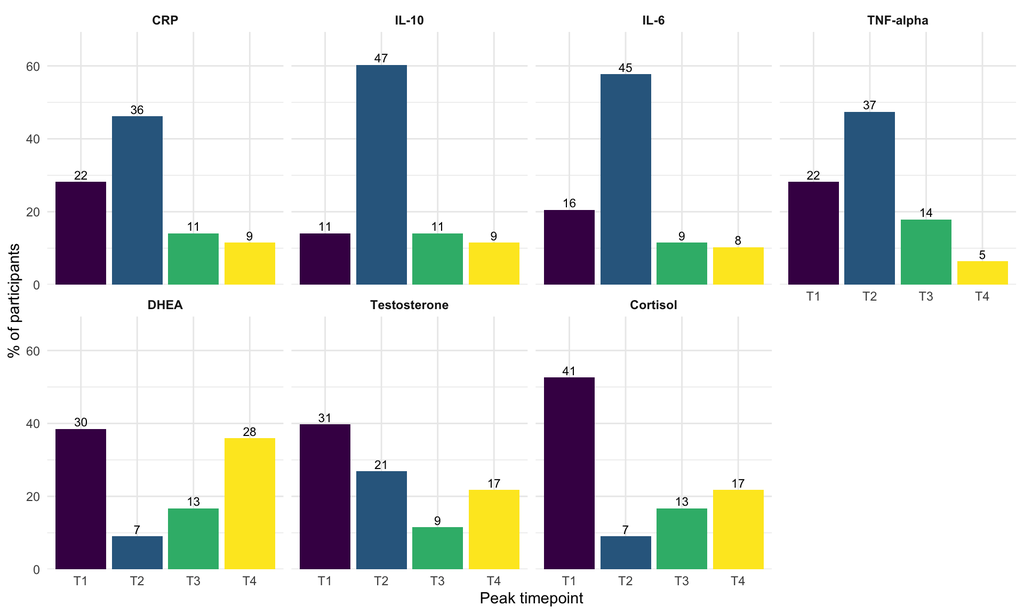

```r
ggplot(peak_timepoint_tbl, aes(x = time_point, y = pct, fill = time_point)) +
  geom_col() +
  geom_text(aes(label = n), vjust = -0.3, size = 3) +
  scale_fill_viridis_d(guide = "none") +
  facet_wrap(~biomarker, nrow = 2) +
  scale_y_continuous(expand = expansion(mult = c(0, 0.15))) +
  labs(x = "Peak timepoint", y = "% of participants") +
  theme_minimal() +
  theme(strip.text = element_text(face = "bold"))
```

**Results.** The modal (most common) peak timepoint for each biomarker was: CRP (T2: n = 36, 46.2%); IL-10 (T2: n = 47, 60.3%); IL-6 (T2: n = 45, 57.7%); TNF-alpha (T2: n = 37, 47.4%); DHEA (T1: n = 30, 38.5%); Testosterone (T1: n = 31, 39.7%); Cortisol (T1: n = 41, 52.6%).

# Hypothesis 1a: Biomarker Time Trends

*Hypothesis 1a (manuscript): “We estimated both the linear and quadratic effects of time point on each immune and hormone biomarker using a random intercept and a random effect of time point nested within participants.”*

## Model Comparison (AIC / BIC)

```r
mlm_list <- list(
  CRP = mlm_crp, `IL-10` = mlm_il10, `IL-6` = mlm_il6, `TNF-alpha` = mlm_tnfalpha,
  DHEA = mlm_dhea, Testosterone = mlm_test, Cortisol = mlm_cort
)

model_comp_tbl <- imap_dfr(mlm_list, function(res, name) {
  tibble(
    biomarker = name,
    Model   = c("Linear", "Quadratic"),
    df      = res$aic$df,
    AIC     = round(res$aic$AIC, 1),
    BIC     = round(res$bic$BIC, 1)
  )
})

best_rows <- model_comp_tbl |>
  group_by(biomarker) |>
  mutate(is_best = AIC == min(AIC)) |>
  ungroup() |>
  pull(is_best)

model_comp_tbl |>
  kable() |>
  kable_styling(bootstrap_options = "hover", full_width = FALSE) |>
  row_spec(which(best_rows), bold = TRUE, color = "#2166ac")
```

| biomarker | Model | df | AIC | BIC |
| --- | --- | --- | --- | --- |
| CRP | Linear | 6 | 1176.6 | 1198.7 |
| CRP | Quadratic | 10 | 1173.4 | 1210.2 |
| IL-10 | Linear | 6 | 741.3 | 763.3 |
| IL-10 | Quadratic | 10 | 703.9 | 740.7 |
| IL-6 | Linear | 6 | 754.3 | 776.4 |
| IL-6 | Quadratic | 10 | 739.2 | 776.0 |
| TNF-alpha | Linear | 6 | 735.7 | 757.8 |
| TNF-alpha | Quadratic | 10 | 708.6 | 745.4 |
| DHEA | Linear | 6 | 522.3 | 544.2 |
| DHEA | Quadratic | 10 | 491.6 | 528.0 |
| Testosterone | Linear | 6 | 262.1 | 284.0 |
| Testosterone | Quadratic | 10 | 252.1 | 288.5 |
| Cortisol | Linear | 6 | 491.8 | 513.7 |
| Cortisol | Quadratic | 10 | 452.7 | 489.2 |

A significant LRT indicates that adding the quadratic time term significantly improves model fit.

```r
lrt_tbl <- imap_dfr(mlm_list, function(res, name) {
  a       <- anova(res$linear, res$quadratic, refit = TRUE)
  p_col   <- grep("Pr", colnames(a), value = TRUE)[1]
  tibble(
    biomarker = name,
    chisq   = round(a$Chisq[2], 2),
    p_raw   = as.numeric(a[2, p_col])
  )
}) |>
  mutate(
    group = c(rep("Immune", 4), rep("Hormones", 3)),
    p_fdr = c(
      p.adjust(p_raw[1:4], method = "fdr"),
      p.adjust(p_raw[5:7], method = "fdr")
    )
  )

lrt_tbl |>
  mutate(
    p_raw_disp = round(p_raw, 4),
    p_fdr_disp = cell_spec(round(p_fdr, 4), bold = p_fdr < 0.05,
      color = if_else(p_fdr < 0.05, "#2166ac", "black"))
  ) |>
  select(biomarker, group, chisq, p_raw_disp, p_fdr_disp) |>
  kable(escape = FALSE,
        col.names = c("biomarker", "Group", "chi-sq", "p (raw)", "p (FDR)"),
        caption = "Likelihood ratio test: quadratic vs. linear (FDR-corrected within immune and hormone groups; bold = p_FDR < .05)") |>
  kable_styling(bootstrap_options = "hover", full_width = FALSE)
```

| biomarker | Group | chi-sq | p (raw) | p (FDR) |
| --- | --- | --- | --- | --- |
| CRP | Immune | 3.01 | 0.5568 | 0.5568 |
| IL-10 | Immune | 38.84 | 0.0000 | 0 |
| IL-6 | Immune | 16.43 | 0.0025 | 0.0033 |
| TNF-alpha | Immune | 28.65 | 0.0000 | 0 |
| DHEA | Hormones | 33.30 | 0.0000 | 0 |
| Testosterone | Hormones | 12.98 | 0.0114 | 0.0114 |
| Cortisol | Hormones | 41.43 | 0.0000 | 0 |

**Results.** We modeled log-transformed biomarker concentrations across four timepoints (T1–T4) using linear mixed models. A quadratic time term provided the lowest AIC for 7 of 7 biomarkers (CRP, Cortisol, DHEA, IL-10, IL-6, TNF-alpha, Testosterone). Likelihood ratio tests (quadratic vs. linear) were FDR-corrected within immune markers and hormones separately; the quadratic term significantly improved fit for 6 biomarkers (IL-10, IL-6, TNF-alpha, DHEA, Testosterone, Cortisol); the improvement was not significant for CRP. Fixed effects are shown below with FDR-corrected p-values within each term across immune markers and hormones separately.

## Fixed Effects: Quadratic Models

```r
# Collect all fixed effects, then FDR-correct within term × group
all_fixed_effects <- imap_dfr(mlm_list, function(res, name) {
  broom.mixed::tidy(res$quadratic, effects = "fixed") |>
    mutate(biomarker = name)
}) |>
  mutate(group = if_else(
    biomarker %in% c("CRP", "IL-10", "IL-6", "TNF-alpha"), "Immune", "Hormones"
  )) |>
  group_by(term, group) |>
  mutate(p_fdr = p.adjust(p.value, method = "fdr")) |>
  ungroup()

iwalk(mlm_list, function(res, name) {
  cat("\n\n### ", name, "\n\n")
  tbl <- all_fixed_effects |>
    filter(biomarker == name) |>
    select(term, estimate, std.error, statistic, df, p.value, p_fdr) |>
    mutate(
      across(c(estimate, std.error, statistic, df), \(x) round(x, 3)),
      p.value = round(p.value, 4),
      p_fdr   = round(p_fdr,   4)
    )
  tbl |>
    mutate(p_fdr = cell_spec(p_fdr, bold = !is.na(p_fdr) & p_fdr < 0.05,
      color = if_else(!is.na(p_fdr) & p_fdr < 0.05, "#2166ac", "black"))) |>
    kable(escape = FALSE,
          col.names = c("Term", "b", "SE", "t", "df", "p (raw)", "p (FDR)")) |>
    kable_styling(bootstrap_options = "hover", full_width = FALSE) |>
    print()
})
```

### CRP

| Term | b | SE | t | df | p (raw) | p (FDR) |
| --- | --- | --- | --- | --- | --- | --- |
| (Intercept) | -2.490 | 0.257 | -9.678 | 76.416 | 0.0000 | 0 |
| poly(Time, 2)1 | -1.836 | 1.335 | -1.375 | 73.127 | 0.1732 | 0.3465 |
| poly(Time, 2)2 | -2.001 | 1.289 | -1.553 | 73.914 | 0.1247 | 0.1247 |

### IL-10

| Term | b | SE | t | df | p (raw) | p (FDR) |
| --- | --- | --- | --- | --- | --- | --- |
| (Intercept) | 1.450 | 0.121 | 11.967 | 76.297 | 0.0000 | 0 |
| poly(Time, 2)1 | 1.357 | 0.617 | 2.201 | 80.805 | 0.0306 | 0.1225 |
| poly(Time, 2)2 | -3.419 | 0.543 | -6.297 | 118.804 | 0.0000 | 0 |

### IL-6

| Term | b | SE | t | df | p (raw) | p (FDR) |
| --- | --- | --- | --- | --- | --- | --- |
| (Intercept) | 0.865 | 0.128 | 6.740 | 76.823 | 0.0000 | 0 |
| poly(Time, 2)1 | -0.666 | 0.630 | -1.057 | 76.348 | 0.2936 | 0.3915 |
| poly(Time, 2)2 | -2.335 | 0.578 | -4.038 | 129.956 | 0.0001 | 0.0001 |

### TNF-alpha

| Term | b | SE | t | df | p (raw) | p (FDR) |
| --- | --- | --- | --- | --- | --- | --- |
| (Intercept) | 1.948 | 0.109 | 17.890 | 74.132 | 0.000 | 0 |
| poly(Time, 2)1 | -0.391 | 0.741 | -0.528 | 73.421 | 0.599 | 0.599 |
| poly(Time, 2)2 | -2.637 | 0.540 | -4.881 | 107.638 | 0.000 | 0 |

### DHEA

| Term | b | SE | t | df | p (raw) | p (FDR) |
| --- | --- | --- | --- | --- | --- | --- |
| (Intercept) | 4.384 | 0.099 | 44.160 | 74.060 | 0.0000 | 0 |
| poly(Time, 2)1 | 1.025 | 0.539 | 1.900 | 70.369 | 0.0615 | 0.0922 |
| poly(Time, 2)2 | 0.830 | 0.381 | 2.179 | 82.249 | 0.0322 | 0.0352 |

### Testosterone

| Term | b | SE | t | df | p (raw) | p (FDR) |
| --- | --- | --- | --- | --- | --- | --- |
| (Intercept) | 3.653 | 0.050 | 73.760 | 75.710 | 0.0000 | 0 |
| poly(Time, 2)1 | -0.384 | 0.297 | -1.291 | 74.304 | 0.2008 | 0.2008 |
| poly(Time, 2)2 | 0.587 | 0.275 | 2.132 | 112.847 | 0.0352 | 0.0352 |

### Cortisol

| Term | b | SE | t | df | p (raw) | p (FDR) |
| --- | --- | --- | --- | --- | --- | --- |
| (Intercept) | -2.003 | 0.060 | -33.547 | 76.163 | 0.0000 | 0 |
| poly(Time, 2)1 | -1.503 | 0.641 | -2.344 | 74.876 | 0.0218 | 0.0653 |
| poly(Time, 2)2 | 1.758 | 0.385 | 4.569 | 72.480 | 0.0000 | 0.0001 |

## Quadratic Curves

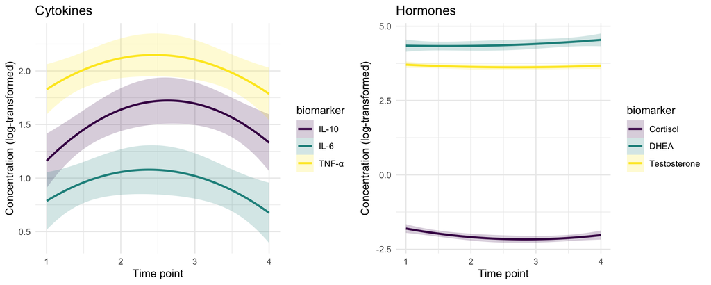

```r
cytokines_long <- sos_cytokines_panel |>
  pivot_longer(c(IL10_log, IL6_log, TNFalpha_log), names_to = "biomarker", values_to = "log_conc") |>
  mutate(biomarker = case_match(
    biomarker,
    "IL10_log"     ~ "IL-10",
    "IL6_log"      ~ "IL-6",
    "TNFalpha_log" ~ "TNF-\u03b1"
  ))

cytokines_quad_plot <- ggplot(cytokines_long, aes(Time, log_conc, color = biomarker)) +
  stat_smooth(method = "lm", formula = y ~ x + I(x^2), linewidth = 1,
              aes(fill = after_scale(colour)), alpha = 0.2) +
  scale_colour_viridis_d() +
  ylab("Concentration (log-transformed)") + xlab("Time point") + ggtitle("Cytokines") + theme_minimal()

hormones_long <- sos_hormones_panel |>
  pivot_longer(c(DHEA_log, Testosterone_log, Cortisol_log), names_to = "biomarker", values_to = "log_conc") |>
  mutate(biomarker = case_match(
    biomarker,
    "DHEA_log"         ~ "DHEA",
    "Testosterone_log" ~ "Testosterone",
    "Cortisol_log"     ~ "Cortisol"
  ))

hormones_quad_plot <- ggplot(hormones_long, aes(Time, log_conc, color = biomarker)) +
  stat_smooth(method = "lm", formula = y ~ x + I(x^2), linewidth = 1,
              aes(fill = after_scale(colour)), alpha = 0.2) +
  scale_colour_viridis_d() +
  ylab("Concentration (log-transformed)") + xlab("Time point") + ggtitle("Hormones") + theme_minimal()

ggarrange(cytokines_quad_plot, hormones_quad_plot, ncol = 2)
```

## Individual Growth Curves

Each person’s observed trajectory (thin grey lines) with individual model-fitted curves (thin coloured lines, based on random slope/intercept estimates) and the population-average quadratic trajectory (thick line).

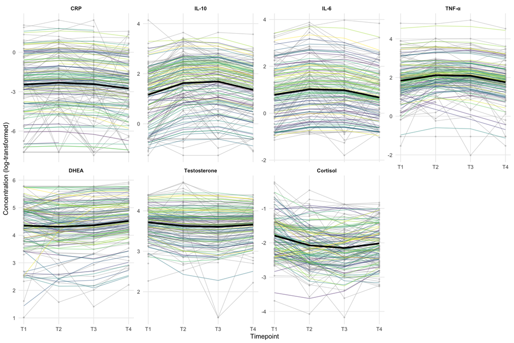

```r
panel_map <- list(
  "CRP"          = list(data = sos_crp_panel,       col = "CRP_log"),
  "IL-10"        = list(data = sos_cytokines_panel, col = "IL10_log"),
  "IL-6"         = list(data = sos_cytokines_panel, col = "IL6_log"),
  "TNF-alpha"    = list(data = sos_cytokines_panel, col = "TNFalpha_log"),
  "DHEA"         = list(data = sos_hormones_panel,  col = "DHEA_log"),
  "Testosterone" = list(data = sos_hormones_panel,  col = "Testosterone_log"),
  "Cortisol"     = list(data = sos_hormones_panel,  col = "Cortisol_log")
)

ind_curve_data <- imap_dfr(mlm_list, function(res, name) {
  pm      <- panel_map[[name]]
  obs_dat <- pm$data |>
    select(SampleID, Time, value = all_of(pm$col)) |>
    filter(!is.na(value))

  obs_dat |>
    mutate(
      fitted_ind = predict(res$quadratic, newdata = obs_dat),
      fitted_pop = predict(res$quadratic, newdata = obs_dat, re.form = NA),
      biomarker    = name
    )
}) |>
  mutate(
    biomarker = recode(biomarker, "TNF-alpha" = "TNF-α"),
    biomarker = factor(biomarker,
      levels = c("CRP", "IL-10", "IL-6", "TNF-α", "DHEA", "Testosterone", "Cortisol"))
  )

pop_curve <- ind_curve_data |>
  group_by(biomarker, Time) |>
  summarise(fitted_pop = mean(fitted_pop, na.rm = TRUE), .groups = "drop")

ggplot(ind_curve_data, aes(x = Time, group = SampleID)) +
  geom_line(aes(y = value),      color = "gray70", linewidth = 0.35, alpha = 0.6) +
  geom_point(aes(y = value),     color = "gray70", size = 0.7,       alpha = 0.5) +
  geom_line(aes(y = fitted_ind, color = SampleID),
            linewidth = 0.5, alpha = 0.45, show.legend = FALSE) +
  geom_line(data = pop_curve,
            aes(x = Time, y = fitted_pop, group = NULL),
            color = "black", linewidth = 1.3, inherit.aes = FALSE) +
  scale_x_continuous(breaks = 1:4, labels = paste0("T", 1:4)) +
  scale_color_viridis_d() +
  facet_wrap(~biomarker, scales = "free_y", ncol = 4) +
  labs(x = "Timepoint", y = "Concentration (log-transformed)") +
  theme_minimal() +
  theme(panel.grid.minor = element_blank(),
        strip.text = element_text(face = "bold"))
```

# Hypothesis 1a (continued): Biomarker Reactivity (Peak vs. Baseline)

*Hypothesis 1a (manuscript): peak (T3 or T4, whichever higher) compared to T1 via one-tailed paired t-tests, FDR-corrected separately within immune markers (4 tests) and hormones (3 tests); reactivity = peak − T1.*

Each person’s peak is the higher of T3 or T4. Reactivity score = peak − T1 (positive = increase from baseline).

## Peak vs. T1 t-tests

```r
peak_ttest_tbl <- peak_tests_raw |>
  map(broom::tidy) |>
  list_rbind(names_to = "biomarker") |>
  mutate(biomarker = case_match(
    biomarker,
    "crp" ~ "CRP", "il10" ~ "IL-10", "il6" ~ "IL-6", "tnfa" ~ "TNF-alpha",
    "dhea" ~ "DHEA", "test" ~ "Testosterone", "cort" ~ "Cortisol"
  )) |>
  select(biomarker, estimate, statistic, parameter, p.value) |>
  mutate(across(where(is.numeric), \(x) round(x, 3)))

peak_ttest_tbl |>
  mutate(p.value = cell_spec(p.value, bold = p.value < 0.05,
    color = if_else(p.value < 0.05, "#2166ac", "black"))) |>
  kable(col.names = c("biomarker", "Mean diff (peak − T1)", "t", "df", "p (one-tailed)"), escape = FALSE) |>
  kable_styling(bootstrap_options = "hover", full_width = FALSE)
```

| biomarker | Mean diff (peak − T1) | t | df | p (one-tailed) |
| --- | --- | --- | --- | --- |
| CRP | 0.407 | 1.851 | 69 | 0.034 |
| IL-10 | 0.581 | 6.278 | 70 | 0 |
| IL-6 | 0.288 | 3.114 | 70 | 0.001 |
| TNF-alpha | 0.329 | 3.344 | 70 | 0.001 |
| DHEA | 0.197 | 2.189 | 66 | 0.016 |
| Testosterone | 0.011 | 0.263 | 66 | 0.397 |
| Cortisol | -0.106 | -1.082 | 66 | 0.858 |

## FDR Correction

```r
fdr_tbl <- tibble(
  group   = c(rep("Immune", 4), rep("Hormones", 3)),
  biomarker = c("CRP", "IL-10", "IL-6", "TNF-alpha", "DHEA", "Testosterone", "Cortisol"),
  p_raw   = round(peak_praw, 6),
  p_fdr   = peak_pfdr
)

fdr_tbl |>
  mutate(p_fdr = cell_spec(round(p_fdr, 4), bold = p_fdr < 0.05,
    color = if_else(p_fdr < 0.05, "#2166ac", "black"))) |>
  kable(col.names = c("Group", "biomarker", "p (raw)", "p (FDR)"), escape = FALSE) |>
  kable_styling(bootstrap_options = "hover", full_width = FALSE)
```

| Group | biomarker | p (raw) | p (FDR) |
| --- | --- | --- | --- |
| Immune | CRP | 0.034235 | 0.0342 |
| Immune | IL-10 | 0.000000 | 0 |
| Immune | IL-6 | 0.001336 | 0.0018 |
| Immune | TNF-alpha | 0.000664 | 0.0013 |
| Hormones | DHEA | 0.016086 | 0.0483 |
| Hormones | Testosterone | 0.396710 | 0.5951 |
| Hormones | Cortisol | 0.858414 | 0.8584 |

**Results.** Biomarker reactivity was operationalized as the difference between each participant’s peak sample (T3 or T4) and baseline (T1). After FDR correction within immune markers and hormones separately, significant baseline-to-peak increases were observed for the following immune markers: CRP, IL-10, IL-6, TNF-alpha; and for the following hormones: DHEA. Testosterone, Cortisol did not show significant hormonal reactivity after FDR correction.

## T3 vs. T4: Which Timepoint Captured the Peak?

*Restricting attention to T3 and T4 only (T2 is excluded here — it may reflect scan-environment arousal or TiM task recording rather than the SOS task itself): for each biomarker, how many participants’ peak (the higher of T3/T4) fell at T3 vs. T4 — both overall, and restricted to participants who showed an actual increase over T1 (“responders”).*

```r
t3_vs_t4_tbl |>
  select(biomarker, n_valid, n_peaked_T3, n_peaked_T4, n_tie) |>
  kable(col.names = c("biomarker", "N (valid T3 & T4)", "Peaked at T3", "Peaked at T4", "Tied"),
        caption = "Which timepoint (T3 or T4) had the higher value, all participants") |>
  kable_styling(bootstrap_options = "hover", full_width = FALSE)
```

Which timepoint (T3 or T4) had the higher value, all participants

| biomarker | N (valid T3 & T4) | Peaked at T3 | Peaked at T4 | Tied |
| --- | --- | --- | --- | --- |
| CRP | 70 | 37 | 29 | 4 |
| IL-10 | 71 | 37 | 30 | 4 |
| IL-6 | 71 | 40 | 22 | 9 |
| TNF-alpha | 71 | 46 | 24 | 1 |
| DHEA | 67 | 24 | 43 | 0 |
| Testosterone | 67 | 24 | 43 | 0 |
| Cortisol | 67 | 33 | 34 | 0 |

```r
t3_vs_t4_tbl |>
  select(biomarker, n_responders, n_resp_peaked_T3, n_resp_peaked_T4) |>
  kable(col.names = c("biomarker", "N responders (peak > T1)", "...peaked at T3", "...peaked at T4"),
        caption = "Among responders only: which timepoint (T3 or T4) captured the peak") |>
  kable_styling(bootstrap_options = "hover", full_width = FALSE)
```

Among responders only: which timepoint (T3 or T4) captured the peak

| biomarker | N responders (peak > T1) | ...peaked at T3 | ...peaked at T4 |
| --- | --- | --- | --- |
| CRP | 40 | 22 | 18 |
| IL-10 | 55 | 30 | 25 |
| IL-6 | 44 | 27 | 16 |
| TNF-alpha | 45 | 31 | 14 |
| DHEA | 41 | 12 | 29 |
| Testosterone | 33 | 11 | 22 |
| Cortisol | 32 | 14 | 18 |

**Results.** Among responders (participants whose peak — the higher of T3 or T4 — exceeded their own T1 baseline), the following biomarkers leaned toward peaking at T3 rather than T4: CRP, IL-10, IL-6, TNF-alpha. The following leaned toward peaking at T4 rather than T3: DHEA, Testosterone, Cortisol.

## Immune Markers

### All (grid)

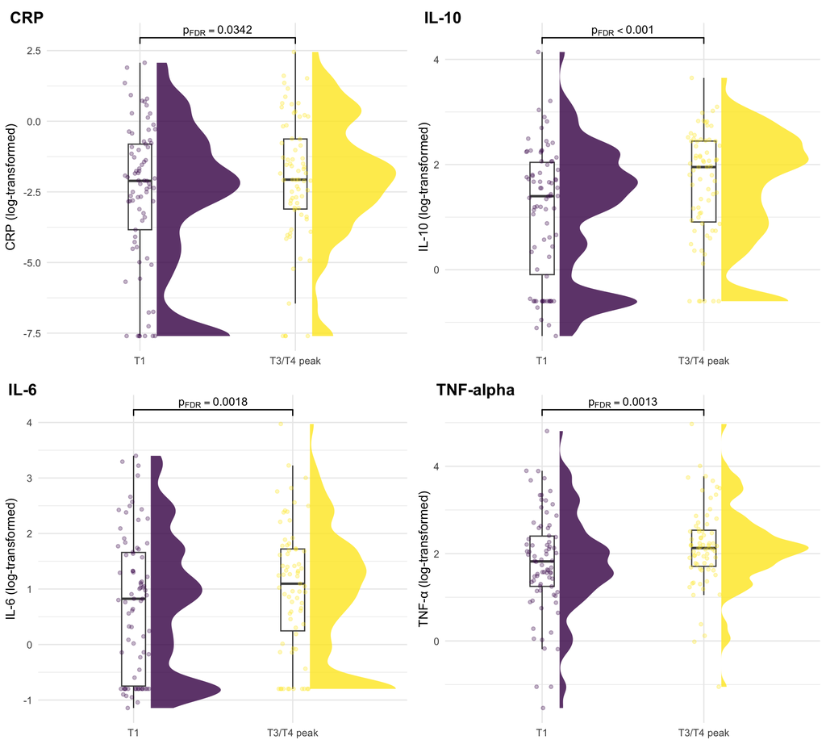

```r
crp_plot  <- biomarker_plot(sos_crp_long,  "crp_log_conc",  "CRP (log-transformed)",        peak_pfdr["crp"])
il10_plot <- biomarker_plot(sos_il10_long, "il10_log_conc", "IL-10 (log-transformed)",       peak_pfdr["il10"])
il6_plot  <- biomarker_plot(sos_il6_long,  "il6_log_conc",  "IL-6 (log-transformed)",        peak_pfdr["il6"])
tnfa_plot <- biomarker_plot(sos_tnfa_long, "tnfa_log_conc", "TNF-\u03b1 (log-transformed)",  peak_pfdr["tnfa"])

ggarrange(crp_plot, il10_plot, il6_plot, tnfa_plot,
  labels = c("CRP", "IL-10", "IL-6", "TNF-alpha"), ncol = 2, nrow = 2,
  hjust = -0.3, vjust = 2)
```

### CRP

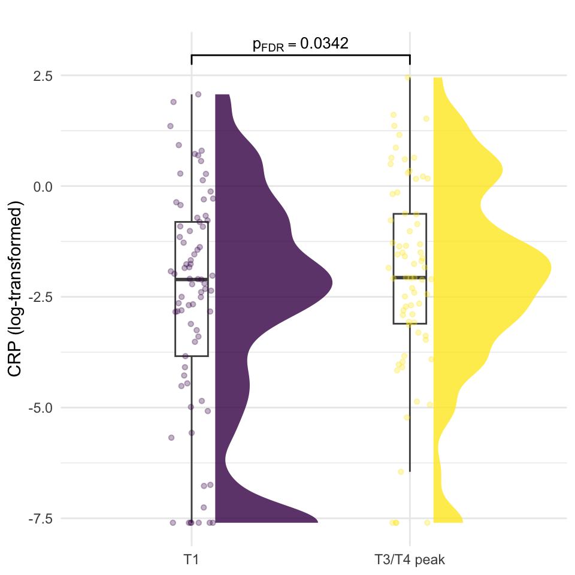

```r
crp_plot
```

### IL-10

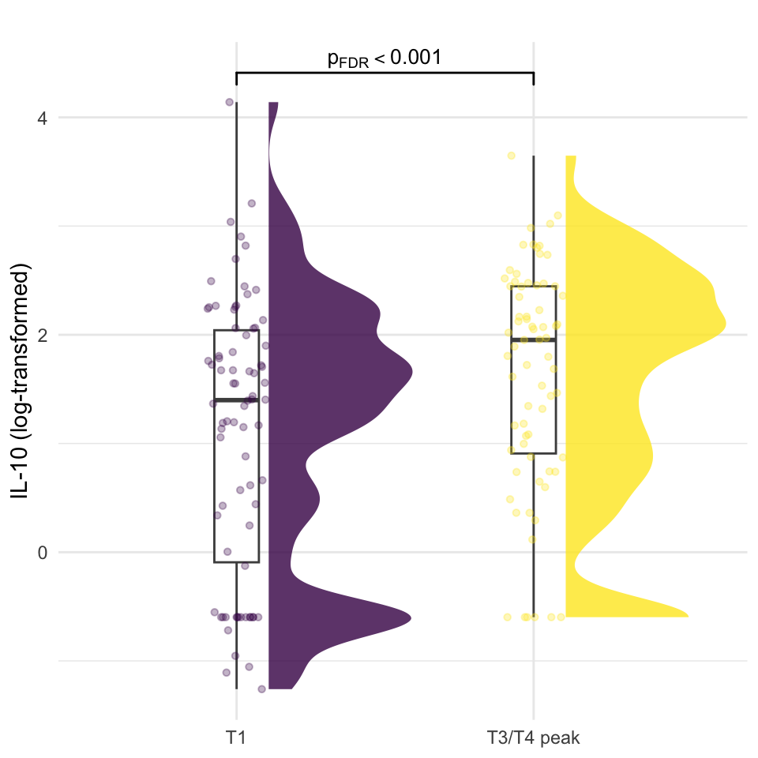

```r
il10_plot
```

### IL-6

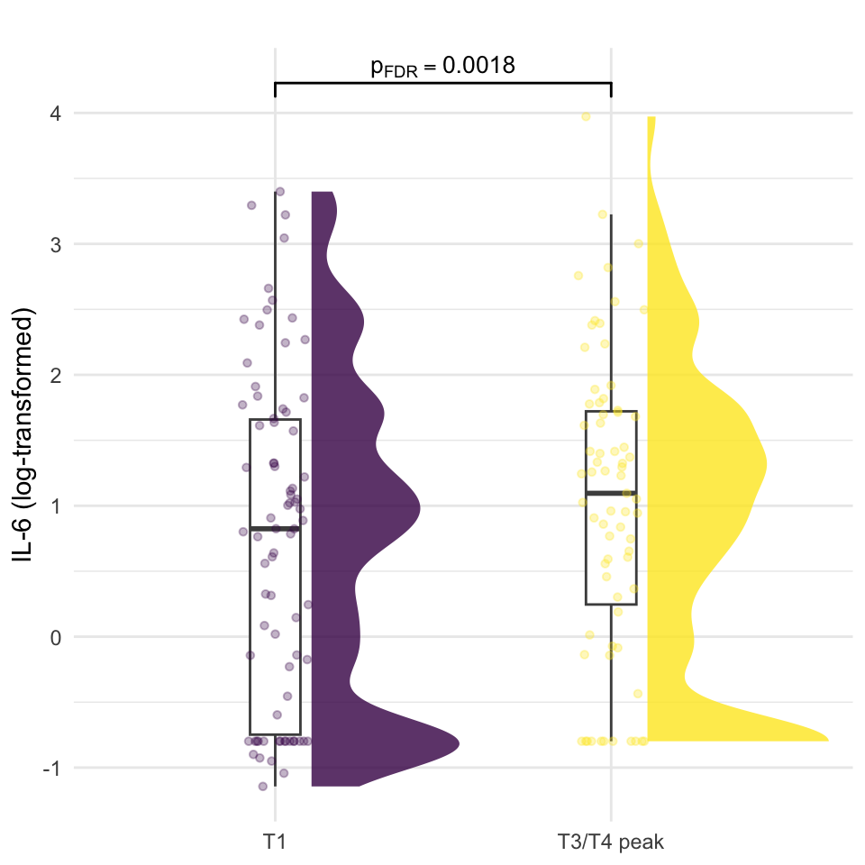

```r
il6_plot
```

### TNF-alpha

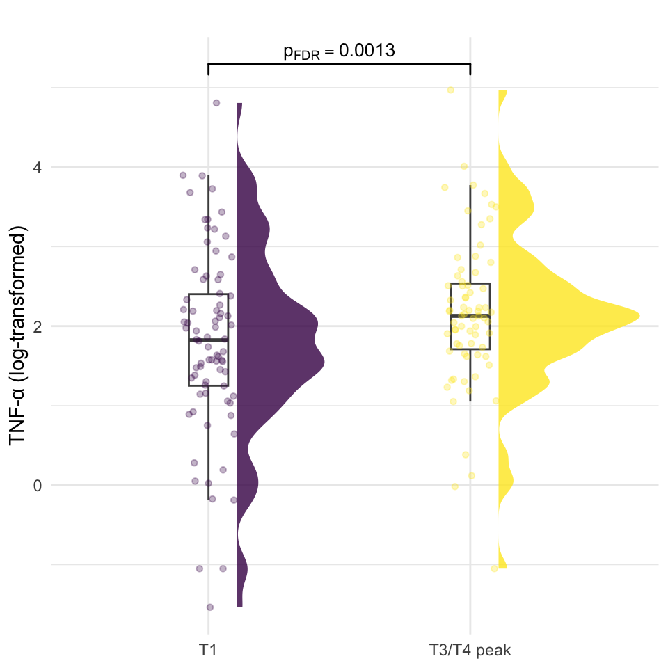

```r
tnfa_plot
```

## Hormones

### All (grid)

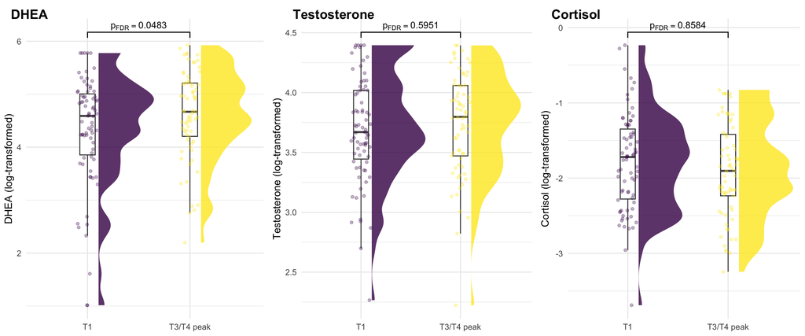

```r
dhea_plot <- biomarker_plot(sos_dhea_long, "dhea_log_conc", "DHEA (log-transformed)",          peak_pfdr["dhea"])
test_plot <- biomarker_plot(sos_test_long, "test_log_conc", "Testosterone (log-transformed)",   peak_pfdr["test"])
cort_plot <- biomarker_plot(sos_cort_long, "cort_log_conc", "Cortisol (log-transformed)",       peak_pfdr["cort"])

ggarrange(dhea_plot, test_plot, cort_plot,
  labels = c("DHEA", "Testosterone", "Cortisol"), ncol = 3, nrow = 1,
  hjust = -0.3, vjust = 2)
```

### DHEA

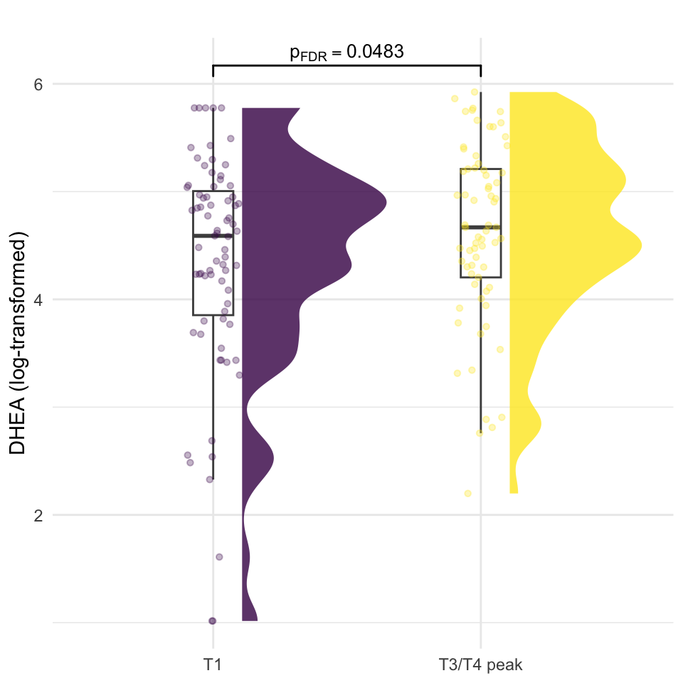

```r
dhea_plot
```

### Testosterone

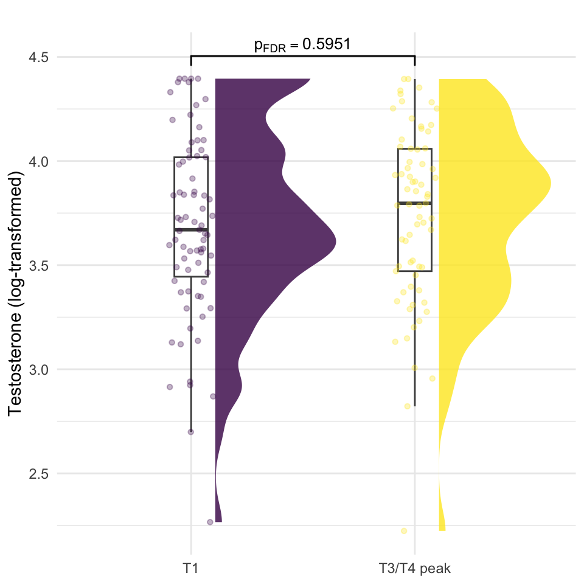

```r
test_plot
```

### Cortisol

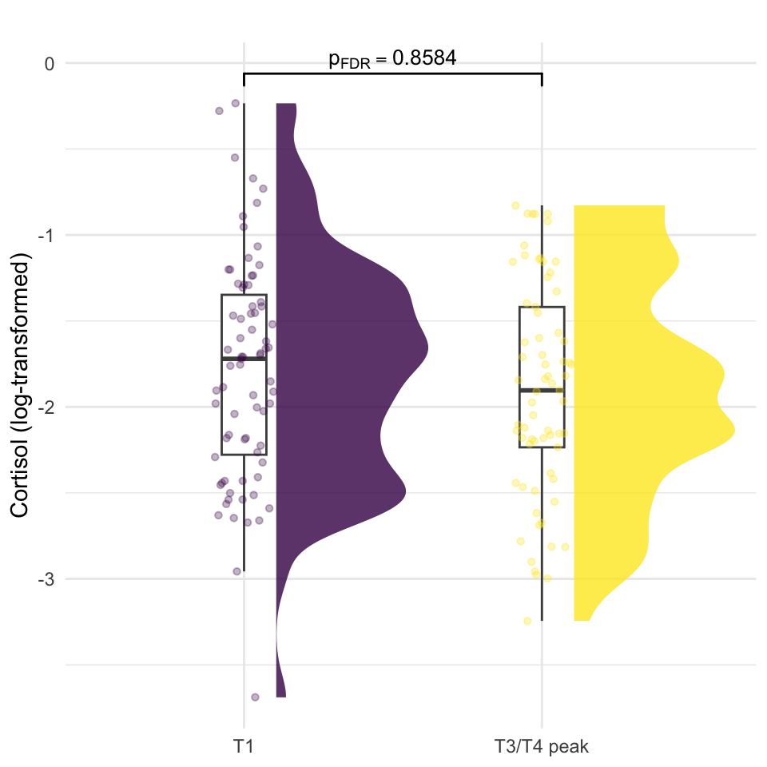

```r
cort_plot
```

## Reactivity Descriptives

```r
bind_rows(
  biomarkers_difference |> select(-SampleID) |> summarise(across(everything(), \(x) mean(x, na.rm = TRUE))) |> mutate(stat = "Mean"),
  biomarkers_difference |> select(-SampleID) |> summarise(across(everything(), \(x) sd(x,   na.rm = TRUE))) |> mutate(stat = "SD")
) |>
  select(stat, everything()) |>
  rename(
    `ΔCRP`          = crp_difference,
    `ΔIL-10`        = il10_difference,
    `ΔIL-6`         = il6_difference,
    `ΔTNF-α`        = tnfa_difference,
    `ΔDHEA`         = dhea_difference,
    `ΔTestosterone` = test_difference,
    `ΔCortisol`     = cort_difference
  ) |>
  kable(digits = 3)
```

| stat | ΔCRP | ΔIL-10 | ΔIL-6 | ΔTNF-α | ΔDHEA | ΔTestosterone | ΔCortisol |
| --- | --- | --- | --- | --- | --- | --- | --- |
| Mean | 0.407 | 0.581 | 0.288 | 0.329 | 0.197 | 0.011 | -0.106 |
| SD | 1.840 | 0.780 | 0.779 | 0.829 | 0.735 | 0.352 | 0.800 |

# Hypothesis 1b: Heart Rate Reactivity

*Hypothesis 1b (manuscript): task heart rate vs. resting-state baseline (two 5-min pre-task scans), and Self-Connected vs. Self-Disconnected/Other/fixation-cross, via one-tailed paired t-tests.*

## Descriptive Means

```r
tibble(
  Condition = c(
    "Resting 1", "Resting 2", "Resting Average", "Task (overall)",
    "Within-task: Fixation-Cross", "Within-task: Other",
    "Within-task: Self-Disconnected", "Within-task: Self-Connected"
  ),
  `Mean HR (bpm)` = round(c(
    mean(hr_all_wide$`Resting 1`),
    mean(hr_all_wide$`Resting 2`, na.rm = TRUE),
    mean(hr_all_wide$resting_avg),
    mean(hr_all_wide$Task),
    mean(pull_hr("Fixation-Cross")),
    mean(pull_hr("Other")),
    mean(pull_hr("Self-Disconnected")),
    mean(pull_hr("Self-Connected"))
  ), 2)
) |>
  kable()
```

| Condition | Mean HR (bpm) |
| --- | --- |
| Resting 1 | 73.44 |
| Resting 2 | 72.37 |
| Resting Average | 72.93 |
| Task (overall) | 76.94 |
| Within-task: Fixation-Cross | 76.96 |
| Within-task: Other | 76.01 |
| Within-task: Self-Disconnected | 77.14 |
| Within-task: Self-Connected | 77.52 |

## HR Difference Score Descriptives

```r
bind_rows(
  hr_difference |> select(-SampleID) |> summarise(across(everything(), \(x) mean(x, na.rm = TRUE))) |> mutate(stat = "Mean"),
  hr_difference |> select(-SampleID) |> summarise(across(everything(), \(x) sd(x,   na.rm = TRUE))) |> mutate(stat = "SD")
) |>
  select(stat, everything()) |>
  rename(
    `ΔHR: Task vs. Rest`  = task_rs_hr_diff,
    `ΔHR: SC vs. SD`      = conn_dis_hr_diff,
    `ΔHR: SC vs. Other`   = conn_other_hr_diff,
    `ΔHR: SC vs. Fixation-Cross` = conn_rest_hr_diff
  ) |>
  kable(digits = 3, caption = "HR reactivity difference scores (positive = higher during more self-connected/active condition)")
```

HR reactivity difference scores (positive = higher during more self-connected/active condition)

| stat | ΔHR: Task vs. Rest | ΔHR: SC vs. SD | ΔHR: SC vs. Other | ΔHR: SC vs. Fixation-Cross |
| --- | --- | --- | --- | --- |
| Mean | 4.015 | 0.374 | 1.510 | 0.557 |
| SD | 3.800 | 1.210 | 1.734 | 1.396 |

## Paired t-tests

```r
hr_ttest_tbl <- list(
  "Task vs. Resting" = t.test(hr_all_wide$Task, hr_all_wide$resting_avg, alternative = "greater", paired = TRUE),
  "Self-Connected vs. Fixation-Cross" = t.test(pull_hr("Self-Connected"), pull_hr("Fixation-Cross"), alternative = "greater", paired = TRUE),
  "Self-Connected vs. Self-Disconnected" = t.test(pull_hr("Self-Connected"), pull_hr("Self-Disconnected"), alternative = "greater", paired = TRUE),
  "Self-Connected vs. Other" = t.test(pull_hr("Self-Connected"), pull_hr("Other"), alternative = "greater", paired = TRUE)
) |>
  map(broom::tidy) |>
  list_rbind(names_to = "comparison") |>
  select(comparison, estimate, statistic, parameter, p.value) |>
  mutate(across(where(is.numeric), \(x) round(x, 3)))

hr_ttest_tbl |>
  mutate(p.value = cell_spec(p.value, bold = p.value < 0.05,
    color = if_else(p.value < 0.05, "#2166ac", "black"))) |>
  kable(col.names = c("Comparison", "Mean diff", "t", "df", "p"), escape = FALSE) |>
  kable_styling(bootstrap_options = "hover", full_width = FALSE)
```

| Comparison | Mean diff | t | df | p |
| --- | --- | --- | --- | --- |
| Task vs. Resting | 4.015 | 7.471 | 49 | 0 |
| Self-Connected vs. Fixation-Cross | 0.557 | 2.822 | 49 | 0.003 |
| Self-Connected vs. Self-Disconnected | 0.374 | 2.187 | 49 | 0.017 |
| Self-Connected vs. Other | 1.510 | 6.156 | 49 | 0 |

**Results.** Heart rate was significantly higher during the SOS task compared to the pre-task resting scan (*M*<sub>diff</sub> = 4.015 bpm, *t*(49) = 7.471, *p* < .001). Within the task, heart rate during the Self-Connected condition was significantly higher than both the Self-Disconnected condition (*M*<sub>diff</sub> = 0.374 bpm, *t*(49) = 2.187, *p* = 0.017) and the Other condition (*M*<sub>diff</sub> = 1.51 bpm, *t*(49) = 6.156, *p* < .001), and compared to the within-task fixation-cross period (*M*<sub>diff</sub> = 0.557 bpm, *t*(49) = 2.822, *p* = 0.003).

## Plots

### Task vs. Resting

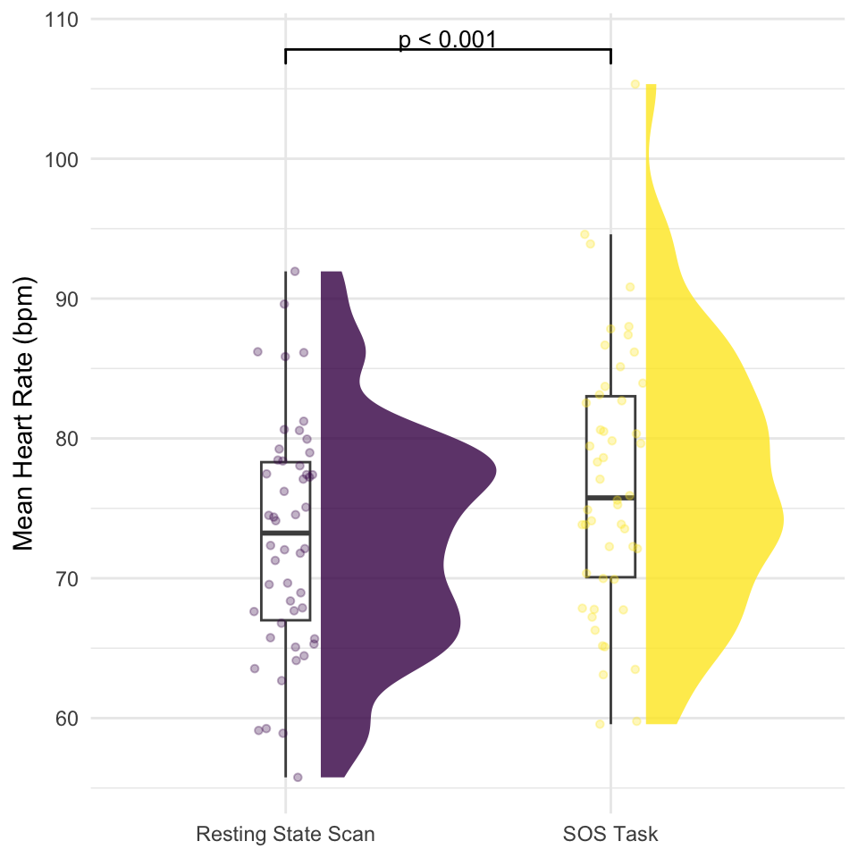

```r
hr_avg_long <- hr_all_wide |>
  select(id, resting_avg, Task) |>
  pivot_longer(
    c(resting_avg, Task),
    names_to = "condition",
    values_to = "mean_hr"
  ) |>
  mutate(
    condition = factor(
      condition,
      levels = c("resting_avg", "Task"),
      labels = c("Resting State Scan", "SOS Task")
    )
  )

ggplot(hr_avg_long, aes(x = condition, y = mean_hr)) +
  stat_halfeye(
    aes(fill = condition),
    adjust = 0.5,
    width = 0.6,
    .width = 0,
    justification = -0.2,
    point_colour = NA,
    alpha = 0.8
  ) +
  geom_boxplot(
    width = 0.15,
    outlier.shape = NA,
    color = "gray30",
    linewidth = 0.5
  ) +
  geom_point(
    aes(color = condition),
    position = position_jitter(seed = 1, width = 0.1),
    size = 1.2,
    alpha = 0.3
  ) +
  scale_fill_viridis_d() +
  scale_color_viridis_d(guide = "none") +
  geom_signif(
    comparisons = list(c("Resting State Scan", "SOS Task")),
    annotations = fmt_p_plain(
      hr_ttest_tbl |> filter(comparison == "Task vs. Resting") |> pull(p.value)
    ),
    tip_length = 0.02, vjust = 0.3, textsize = 3.5
  ) +
  ylab("Mean Heart Rate (bpm)") +
  xlab(NULL) +
  theme_minimal() +
  theme(legend.position = "none")
```

### Within-task Conditions

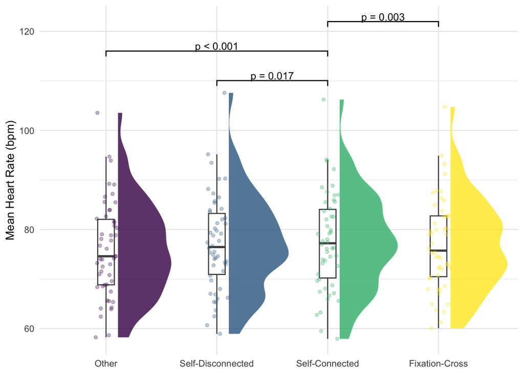

```r
task_hr_comparisons <- list(
  c("Self-Connected", "Self-Disconnected"),
  c("Self-Connected", "Other"),
  c("Self-Connected", "Fixation-Cross")
)

ggplot(hr_conditions_avg, aes(x = task_condition, y = mean_hr)) +
  stat_halfeye(
    aes(fill = task_condition),
    adjust = 0.5, width = 0.6, .width = 0,
    justification = -0.2, point_colour = NA, alpha = 0.8
  ) +
  geom_boxplot(width = 0.15, outlier.shape = NA, color = "gray30", linewidth = 0.5) +
  geom_point(
    aes(color = task_condition),
    position = position_jitter(seed = 1, width = 0.1),
    size = 1.2, alpha = 0.3
  ) +
  scale_fill_viridis_d() +
  scale_color_viridis_d(guide = "none") +
  geom_signif(
    comparisons = task_hr_comparisons,
    annotations = c(
      fmt_p_plain(hr_ttest_tbl |> filter(comparison == "Self-Connected vs. Self-Disconnected") |> pull(p.value)),
      fmt_p_plain(hr_ttest_tbl |> filter(comparison == "Self-Connected vs. Other")             |> pull(p.value)),
      fmt_p_plain(hr_ttest_tbl |> filter(comparison == "Self-Connected vs. Fixation-Cross")     |> pull(p.value))
    ),
    step_increase = 0.12, tip_length = 0.02, vjust = 0.3, textsize = 3.5
  ) +
  ylab("Mean Heart Rate (bpm)") + xlab(NULL) + theme_minimal() + theme(legend.position = "none")
```

# Hypothesis 1c: Subjective Stress Reactivity

*Hypothesis 1c (manuscript): Self-Connected Likert stress ratings vs. Self-Disconnected and Other, via Wilcoxon signed-rank tests (ordinal ratings).*

## Descriptives

```r
bind_rows(
  subjective_difference |> select(-SampleID) |> summarise(across(everything(), \(x) mean(x, na.rm = TRUE))) |> mutate(stat = "Mean"),
  subjective_difference |> select(-SampleID) |> summarise(across(everything(), \(x) sd(x,   na.rm = TRUE))) |> mutate(stat = "SD")
) |>
  select(stat, everything()) |>
  rename(
    `ΔSubjective Stress: SC vs. SD`    = subj_scsd_difference,
    `ΔSubjective Stress: SC vs. Other` = subj_scother_difference
  ) |>
  kable(digits = 3, caption = "Subjective stress difference scores (positive = higher stress during Self-Connected)")
```

Subjective stress difference scores (positive = higher stress during Self-Connected)

| stat | ΔSubjective Stress: SC vs. SD | ΔSubjective Stress: SC vs. Other |
| --- | --- | --- |
| Mean | 1.313 | 1.881 |
| SD | 1.362 | 1.343 |

## Plot

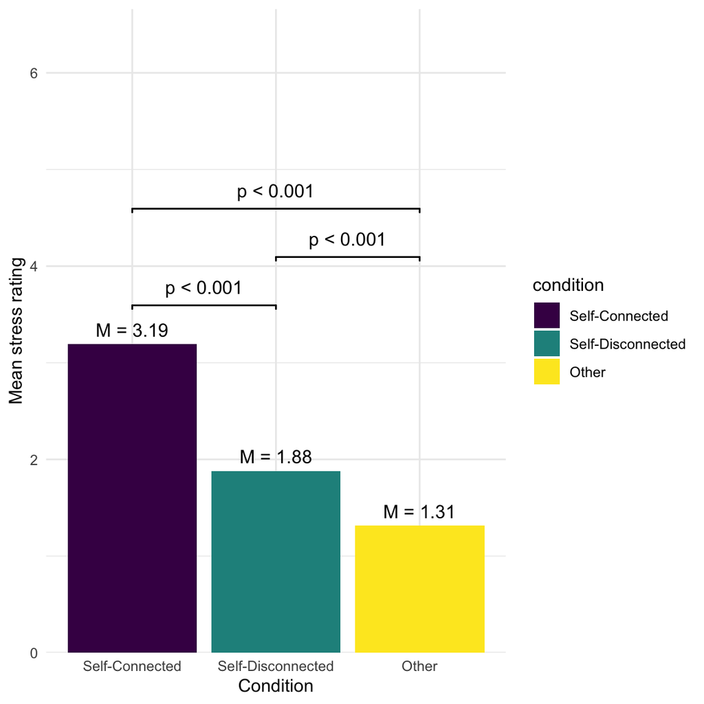

```r
subj_plot
```

**Results.** Participants reported the highest subjective stress during the Self-Connected condition (*M* = 3.19, *SD* = 1.34), relative to both the Self-Disconnected condition (*M* = 1.88, *SD* = 1.15; Wilcoxon *W* = 1410, *p* < .001) and the Other condition (*M* = 1.31, *SD* = 0.76; Wilcoxon *W* = 1582, *p* < .001).

# Hypothesis 1d: Correlations Among Reactivity Measures

*Hypothesis 1d (manuscript): bivariate Pearson correlations among all magnitude-of-change (reactivity) difference scores.*

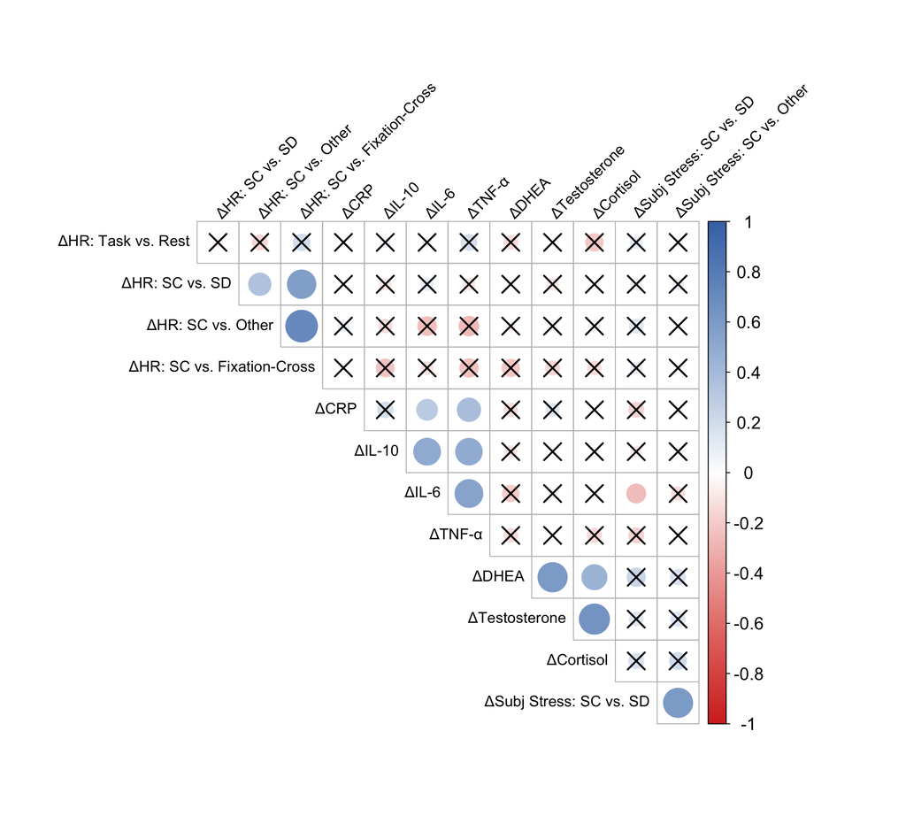

```r
diff_matrix <- all_difference |> select(-SampleID) |> as.matrix()
colnames(diff_matrix) <- c(
  "ΔHR: Task vs. Rest", "ΔHR: SC vs. SD", "ΔHR: SC vs. Other", "ΔHR: SC vs. Fixation-Cross",
  "ΔCRP", "ΔIL-10", "ΔIL-6", "ΔTNF-α", "ΔDHEA", "ΔTestosterone", "ΔCortisol",
  "ΔSubj Stress: SC vs. SD", "ΔSubj Stress: SC vs. Other"
)
difference_rcorrs <- rcorr(diff_matrix)

plot_sig_corrplot <- function(r_mat, p_mat, title = "", type = "upper",
                              cl.ratio = 0.15, cl.cex = 1.15,
                              tl.cex = 1.0, mar = NULL, diag = FALSE) {
  if (is.null(mar)) {
    mar <- c(0, 0, if (nchar(title) > 0) 2 else 0, 0)
  }
  corrplot(
    r_mat,
    p.mat     = p_mat,
    sig.level = 0.05,
    insig     = "pch",
    pch       = 4,
    pch.col   = "black",
    pch.cex   = 2.5,
    method    = "circle",
    type      = type,
    tl.col    = "black",
    tl.srt    = 45,
    tl.cex    = tl.cex,
    col       = colorRampPalette(c("#d73027", "white", "#4575b4"))(200),
    diag      = diag,
    title     = title,
    mar       = mar,
    cl.ratio  = cl.ratio,
    cl.cex    = cl.cex
  )
}

diff_domains <- list(
  hr      = 1:4,
  immune  = 5:8,
  hormone = 9:11,
  subj    = 12:13
)

fdr_diff_mat <- difference_rcorrs$P
for (idx in diff_domains) {
  sub <- fdr_diff_mat[idx, idx, drop = FALSE]
  ut  <- upper.tri(sub)
  sub[ut] <- p.adjust(sub[ut], method = "fdr")
  sub[lower.tri(sub)] <- t(sub)[lower.tri(sub)]
  fdr_diff_mat[idx, idx] <- sub
}

plot_sig_corrplot(difference_rcorrs$r, fdr_diff_mat)
```

*Circle size and color reflect correlation magnitude (red = negative, blue = positive). X marks indicate non-significant correlations after FDR correction (p<sub>FDR</sub> ≥ .05). FDR applied within domain (HR, immune markers, hormones, subjective stress); cross-domain pairs shown at raw p.*

## Correlation p-values

```r
# fdr_diff_mat already computed in corr-matrix chunk above
fdr_diff_mat |>
  as.data.frame() |>
  mutate(across(everything(), \(x) {
    sig  <- !is.na(x) & x < 0.05
    xlab <- if_else(is.na(x), "—", as.character(round(x, 4)))
    cell_spec(xlab, bold = sig, color = if_else(sig, "#2166ac", "black"))
  })) |>
  kable(escape = FALSE,
        caption = "P-values FDR-corrected within domain (HR, immune, hormones, subjective stress); cross-domain pairs raw (bold = p < .05).") |>
  kable_styling(bootstrap_options = "hover")
```

|  | ΔHR: Task vs. Rest | ΔHR: SC vs. SD | ΔHR: SC vs. Other | ΔHR: SC vs. Fixation-Cross | ΔCRP | ΔIL-10 | ΔIL-6 | ΔTNF-α | ΔDHEA | ΔTestosterone | ΔCortisol | ΔSubj Stress: SC vs. SD | ΔSubj Stress: SC vs. Other |
| --- | --- | --- | --- | --- | --- | --- | --- | --- | --- | --- | --- | --- | --- |
| ΔHR: Task vs. Rest | — | 0.6698 | 0.325 | 0.2755 | 0.853 | 0.5992 | 0.6624 | 0.2182 | 0.3653 | 0.8974 | 0.1467 | 0.4548 | 0.7793 |
| ΔHR: SC vs. SD | 0.6698 | — | 0.0244 | 0 | 0.8817 | 0.5043 | 0.4688 | 0.4952 | 0.9832 | 0.5097 | 0.9174 | 0.5443 | 0.5324 |
| ΔHR: SC vs. Other | 0.325 | 0.0244 | — | 0 | 0.5367 | 0.3792 | 0.0882 | 0.0621 | 0.666 | 0.6176 | 0.555 | 0.3335 | 0.9977 |
| ΔHR: SC vs. Fixation-Cross | 0.2755 | 0 | 0 | — | 0.7341 | 0.1202 | 0.4592 | 0.0994 | 0.1452 | 0.3353 | 0.3894 | 0.5246 | 0.8621 |
| ΔCRP | 0.853 | 0.8817 | 0.5367 | 0.7341 | — | 0.1548 | 0.0122 | 0.0015 | 0.3002 | 0.3352 | 0.886 | 0.2013 | 0.7116 |
| ΔIL-10 | 0.5992 | 0.5043 | 0.3792 | 0.1202 | 0.1548 | — | 0 | 0 | 0.4117 | 0.9845 | 0.7167 | 0.4929 | 0.6864 |
| ΔIL-6 | 0.6624 | 0.4688 | 0.0882 | 0.4592 | 0.0122 | 0 | — | 0 | 0.1134 | 0.671 | 0.8897 | 0.0396 | 0.3206 |
| ΔTNF-α | 0.2182 | 0.4952 | 0.0621 | 0.0994 | 0.0015 | 0 | 0 | — | 0.2848 | 0.9542 | 0.249 | 0.1951 | 0.9399 |
| ΔDHEA | 0.3653 | 0.9832 | 0.666 | 0.1452 | 0.3002 | 0.4117 | 0.1134 | 0.2848 | — | 0 | 0.0002 | 0.0618 | 0.2026 |
| ΔTestosterone | 0.8974 | 0.5097 | 0.6176 | 0.3353 | 0.3352 | 0.9845 | 0.671 | 0.9542 | 0 | — | 0 | 0.2901 | 0.2508 |
| ΔCortisol | 0.1467 | 0.9174 | 0.555 | 0.3894 | 0.886 | 0.7167 | 0.8897 | 0.249 | 0.0002 | 0 | — | 0.2034 | 0.1168 |
| ΔSubj Stress: SC vs. SD | 0.4548 | 0.5443 | 0.3335 | 0.5246 | 0.2013 | 0.4929 | 0.0396 | 0.1951 | 0.0618 | 0.2901 | 0.2034 | — | 0 |
| ΔSubj Stress: SC vs. Other | 0.7793 | 0.5324 | 0.9977 | 0.8621 | 0.7116 | 0.6864 | 0.3206 | 0.9399 | 0.2026 | 0.2508 | 0.1168 | 0 | — |

**Results.** Bivariate Pearson correlations among the 13 reactivity difference scores are shown in the matrix above (full p-value table below). P-values were FDR-corrected within domain (among the four HR reactivity measures, among immune markers, among hormones, and among subjective stress ratings); cross-domain pairs are reported at raw p. Of 78 unique pairs, 13 were statistically significant (ranging from r = -0.25 to r = 0.71). Within-domain associations tended to be positive, reflecting coherence within each response system. Cross-domain associations between physiological and subjective reactivity are reported in context throughout the sections below.

# Hypothesis 2: Puberty and Reactivity

*Hypothesis 2 (manuscript): bivariate Pearson correlations between each of the 13 reactivity outcomes and pubertal status (PDS score average), and three operationalizations of pubertal timing: (1) status-for-age (effect of pubertal status while controlling for age), (2) perceived pubertal timing reported from the PDS and (3) age at menarche.*

Note: pubertal status is tested here using the PUBcomp composite (PDS+line drawings composite), computed in `pubcomp-SOS.R` from `data/SOS-pubcomp.csv`. Age at menarche and self-reported perceived timing (PDS F5) still come from the raw PDS questionnaire, since those items are not carried forward into `SOS-pubcomp.csv`. Both puberty and age are centered in the first timing operationalization.

## Puberty Descriptives

```r
sos_puberty |>
  select(-SampleID) |>
  summarise(across(everything(), list(
    Mean = \(x) round(mean(x, na.rm = TRUE), 2),
    SD   = \(x) round(sd(x,   na.rm = TRUE), 2),
    Min  = \(x) round(min(x,  na.rm = TRUE), 2),
    Max  = \(x) round(max(x,  na.rm = TRUE), 2),
    N    = \(x) sum(!is.na(x))
  ))) |>
  pivot_longer(everything(), names_to = c("variable", "stat"), names_sep = "_(?=[^_]+$)") |>
  pivot_wider(names_from = stat, values_from = value) |>
  mutate(variable = recode(variable, !!!puberty_label_map)) |>
  kable(caption = "Puberty variable descriptives") |>
  kable_styling(bootstrap_options = "hover", full_width = FALSE)
```

Puberty variable descriptives

| variable | Mean | SD | Min | Max | N |
| --- | --- | --- | --- | --- | --- |
| Pubertal Status (Composite) | 4.15 | 0.65 | 2.25 | 5 | 77 |

## Correlations: All Puberty Variables × Reactivity

Rows include pubertal status (PDS+line drawings composite), age at menarche, and PDS F5 perceived timing; columns are all reactivity outcomes.

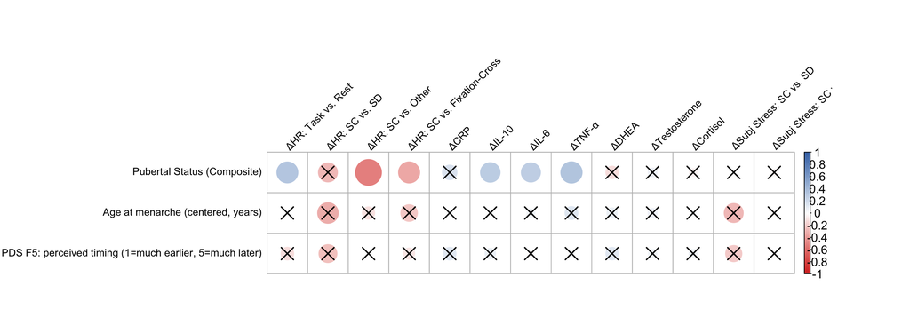

```r
all_pub_vars   <- c(puberty_vars, timing_vars)
all_pub_labels <- c(puberty_labels, timing_labels)

all_pub_mat <- timing_reactivity |>
  select(all_of(c(all_pub_vars, reactivity_vars))) |>
  as.matrix()
colnames(all_pub_mat) <- c(all_pub_labels, reactivity_labels)

all_pub_corrs   <- rcorr(all_pub_mat)
pub_react_corrs <- all_pub_corrs   # alias for downstream inline text

# FDR computed HERE so corrplot and table use identical p-values.
# Each puberty/timing variable is its own family, corrected separately within
# each reactivity domain (e.g. PUBcomp x HR is one family, PUBcomp x hormones
# is a separate family, age at menarche x HR is yet another separate family).
hr_cols   <- reactivity_labels[1:4]
imm_cols  <- reactivity_labels[5:8]
horm_cols <- reactivity_labels[9:11]
subj_cols <- reactivity_labels[12:13]

raw_allpub_mat <- all_pub_corrs$P[all_pub_labels, reactivity_labels, drop = FALSE]
fdr_allpub_mat <- raw_allpub_mat
for (pv in all_pub_labels) {
  for (cols in list(hr_cols, imm_cols, horm_cols, subj_cols)) {
    fdr_allpub_mat[pv, cols] <- p.adjust(raw_allpub_mat[pv, cols], method = "fdr")
  }
}

# X marks reflect FDR-corrected significance (matches the table below)
plot_sig_corrplot(
  all_pub_corrs$r[all_pub_labels, reactivity_labels, drop = FALSE],
  fdr_allpub_mat,
  type = "full", cl.ratio = 0.06, cl.cex = 1.1,
  tl.cex = 0.95, mar = c(0, 0, 1, 6), diag = TRUE
)
```

*X marks indicate non-significant correlations after FDR correction (p<sub>FDR</sub> ≥ .05). FDR applied separately for each puberty/timing variable, within each reactivity domain.*

## Correlation p-values: All Puberty Variables × Reactivity

```r
# fdr_allpub_mat already computed in all-puberty-corr-matrix chunk above
fdr_allpub_mat |>
  as.data.frame() |>
  mutate(across(everything(), \(x) {
    sig  <- !is.na(x) & x < 0.05
    xlab <- if_else(is.na(x), "—", as.character(round(x, 4)))
    cell_spec(xlab, bold = sig, color = if_else(sig, "#2166ac", "black"))
  })) |>
  kable(escape = FALSE,
        caption = "FDR-adjusted p-values: all puberty variables × reactivity (bold = p_FDR < .05)") |>
  kable_styling(bootstrap_options = "hover")
```

|  | ΔHR: Task vs. Rest | ΔHR: SC vs. SD | ΔHR: SC vs. Other | ΔHR: SC vs. Fixation-Cross | ΔCRP | ΔIL-10 | ΔIL-6 | ΔTNF-α | ΔDHEA | ΔTestosterone | ΔCortisol | ΔSubj Stress: SC vs. SD | ΔSubj Stress: SC vs. Other |
| --- | --- | --- | --- | --- | --- | --- | --- | --- | --- | --- | --- | --- | --- |
| Pubertal Status (Composite) | 0.0268 | 0.058 | 0.001 | 0.0268 | 0.1818 | 0.0257 | 0.0257 | 0.0147 | 0.7139 | 0.7139 | 0.7139 | 0.9822 | 0.9822 |
| Age at menarche (centered, years) | 0.9995 | 0.2406 | 0.669 | 0.4424 | 0.9727 | 0.9727 | 0.9727 | 0.9727 | 0.8553 | 0.8553 | 0.8553 | 0.1283 | 0.8666 |
| PDS F5: perceived timing (1=much earlier, 5=much later) | 0.6731 | 0.3667 | 0.9573 | 0.6731 | 0.8612 | 0.8612 | 0.8612 | 0.8612 | 0.6472 | 0.6472 | 0.6472 | 0.2113 | 0.8827 |

## Correlation r-values: All Puberty Variables × Reactivity

```r
r_mat  <- all_pub_corrs$r[all_pub_labels, reactivity_labels, drop = FALSE]
sig_mat <- fdr_allpub_mat < 0.05   # same dimensions

# Build formatted data frame cell by cell
r_df <- as.data.frame(
  matrix(
    mapply(function(r, sig) {
      cell_spec(round(r, 3),
                bold  = sig,
                color = if_else(sig, "#2166ac", "black"))
    }, r_mat, sig_mat),
    nrow = nrow(r_mat), ncol = ncol(r_mat),
    dimnames = dimnames(r_mat)
  )
)

r_df |>
  kable(escape = FALSE,
        caption = "Pearson r: all puberty variables × reactivity (bold = FDR-significant, p_FDR < .05)") |>
  kable_styling(bootstrap_options = "hover")
```

|  | ΔHR: Task vs. Rest | ΔHR: SC vs. SD | ΔHR: SC vs. Other | ΔHR: SC vs. Fixation-Cross | ΔCRP | ΔIL-10 | ΔIL-6 | ΔTNF-α | ΔDHEA | ΔTestosterone | ΔCortisol | ΔSubj Stress: SC vs. SD | ΔSubj Stress: SC vs. Other |
| --- | --- | --- | --- | --- | --- | --- | --- | --- | --- | --- | --- | --- | --- |
| Pubertal Status (Composite) | 0.338 | -0.279 | -0.511 | -0.343 | 0.165 | 0.294 | 0.283 | 0.348 | -0.122 | 0.063 | -0.047 | 0.003 | -0.035 |
| Age at menarche (centered, years) | 0 | -0.326 | -0.119 | -0.215 | 0.026 | 0.005 | 0.051 | 0.131 | 0.084 | 0.067 | 0.028 | -0.278 | -0.026 |
| PDS F5: perceived timing (1=much earlier, 5=much later) | -0.126 | -0.249 | -0.008 | -0.1 | 0.125 | 0.087 | -0.022 | 0.023 | 0.123 | 0.058 | 0.059 | -0.204 | -0.019 |

**Results.** Across the 39 puberty/timing-variable × reactivity-outcome pairs tested (pubertal status — PDS+line drawings composite — plus age at menarche and PDS F5 perceived timing, each against all 13 reactivity outcomes; FDR-corrected within each reactivity domain), 6 associations remained significant after correction: Pubertal Status (Composite) × ΔHR: Task vs. Rest (r = 0.338, p<sub>FDR</sub> = 0.0268); Pubertal Status (Composite) × ΔHR: SC vs. Other (r = -0.511, p<sub>FDR</sub> = 0.001); Pubertal Status (Composite) × ΔHR: SC vs. Fixation-Cross (r = -0.343, p<sub>FDR</sub> = 0.0268); Pubertal Status (Composite) × ΔIL-10 (r = 0.294, p<sub>FDR</sub> = 0.0257); Pubertal Status (Composite) × ΔIL-6 (r = 0.283, p<sub>FDR</sub> = 0.0257); Pubertal Status (Composite) × ΔTNF-α (r = 0.348, p<sub>FDR</sub> = 0.0147). No other puberty or timing variable was significantly associated with reactivity after FDR correction.

## Puberty Status as Predictor of Reactivity

Simple regressions: reactivity ~ pubertal status (mean-centered).

```r
pv_c <- paste0(puberty_vars, "_c")   # centered counterparts

for (i in seq_along(puberty_vars)) {
  pv  <- puberty_vars[i]
  pvc <- pv_c[i]
  cat("\n\n###", puberty_labels[i], "(centered)\n\n")
  reg_tbl <- map_dfr(setNames(reactivity_vars, reactivity_labels), function(rv) {
    dat <- puberty_reactivity |> select(all_of(c(rv, pvc))) |> na.omit()
    if (nrow(dat) < 5) return(NULL)
    fit <- lm(as.formula(paste(rv, "~", pvc)), data = dat)
    broom::tidy(fit) |>
      filter(term != "(Intercept)") |>
      mutate(term = pv, outcome = rv, .before = 1)
  }, .id = "Reactivity") |>
    select(Reactivity, estimate, std.error, statistic, p.value) |>
    mutate(p_fdr = round(p.adjust(p.value, method = "fdr"), 4)) |>
    mutate(across(c(estimate, std.error, statistic), \(x) round(x, 3))) |>
    mutate(p.value = round(p.value, 4))

  reg_tbl |>
    mutate(
      p.value = as.character(p.value),
      p_fdr   = cell_spec(p_fdr, bold = !is.na(p_fdr) & p_fdr < 0.05,
        color = if_else(!is.na(p_fdr) & p_fdr < 0.05, "#2166ac", "black"))
    ) |>
    kable(escape = FALSE,
          col.names = c("Reactivity outcome", "b", "SE", "t", "p (raw)", "p (FDR)")) |>
    kable_styling(bootstrap_options = "hover", full_width = FALSE) |>
    print()
}
```

### Pubertal Status (Composite) (centered)

| Reactivity outcome | b | SE | t | p (raw) | p (FDR) |
| --- | --- | --- | --- | --- | --- |
| ΔHR: Task vs. Rest | 1.818 | 0.857 | 2.122 | 0.039 | 0.0845 |
| ΔHR: SC vs. SD | -0.549 | 0.274 | -2.002 | 0.051 | 0.0947 |
| ΔHR: SC vs. Other | -1.280 | 0.365 | -3.510 | 0.001 | 0.0128 |
| ΔHR: SC vs. Fixation-Cross | -0.697 | 0.313 | -2.224 | 0.0309 | 0.0804 |
| ΔCRP | 0.467 | 0.331 | 1.409 | 0.1633 | 0.2654 |
| ΔIL-10 | 0.349 | 0.136 | 2.574 | 0.0122 | 0.0455 |
| ΔIL-6 | 0.342 | 0.136 | 2.521 | 0.014 | 0.0455 |
| ΔTNF-α | 0.426 | 0.142 | 3.001 | 0.0037 | 0.0244 |
| ΔDHEA | -0.129 | 0.138 | -0.932 | 0.3546 | 0.5123 |
| ΔTestosterone | 0.046 | 0.066 | 0.696 | 0.4891 | 0.6358 |
| ΔCortisol | -0.002 | 0.151 | -0.011 | 0.9915 | 0.9915 |
| ΔSubj Stress: SC vs. SD | 0.062 | 0.264 | 0.235 | 0.8146 | 0.9628 |
| ΔSubj Stress: SC vs. Other | 0.030 | 0.260 | 0.117 | 0.9071 | 0.9827 |

## Scatter Plots: Puberty × Biomarker Reactivity

```r
bio_react_labels <- c(
  crp_difference = "ΔCRP",
  il10_difference = "ΔIL-10",
  il6_difference = "ΔIL-6",
  tnfa_difference = "ΔTNF-α",
  dhea_difference = "ΔDHEA",
  test_difference = "ΔTestosterone",
  cort_difference = "ΔCortisol"
)
bio_react_vars <- names(bio_react_labels)

for (pv in puberty_vars) {
  pv_label <- puberty_label_map[[pv]]
  cat("\n\n###", pv_label, "\n\n")
  pdat <- puberty_reactivity |>
    select(all_of(c(pv, bio_react_vars))) |>
    pivot_longer(
      -all_of(pv),
      names_to = "biomarker",
      values_to = "reactivity"
    ) |>
    mutate(
      biomarker = factor(
        biomarker,
        levels = bio_react_vars,
        labels = unname(bio_react_labels)
      )
    )

  p <- ggplot(pdat, aes(x = .data[[pv]], y = reactivity)) +
    geom_point(alpha = 0.35, size = 1.5) +
    geom_smooth(
      method = "loess",
      formula = y ~ x,
      se = TRUE,
      color = "#440154FF",
      fill = "#440154FF",
      alpha = 0.15,
      linewidth = 0.9
    ) +
    facet_wrap(~biomarker, nrow = 2, scales = "free_y") +
    labs(x = pv_label, y = "Reactivity (peak − T1, log scale)") +
    theme_minimal(base_size = 10)
  print(p)
}
```

### Pubertal Status (Composite)

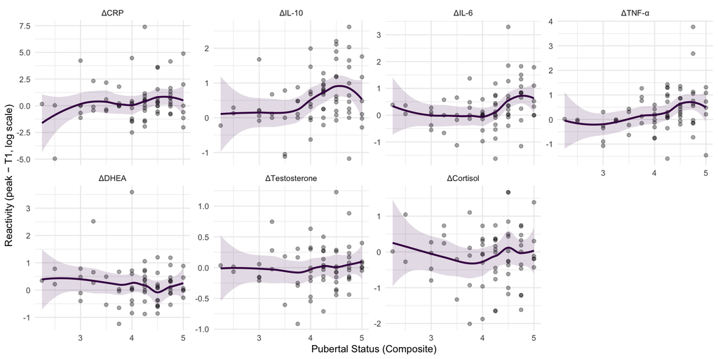

**Results.** Pearson correlations between pubertal status (Pubertal Status (Composite)) and all 13 reactivity outcomes revealed 6 significant associations at *p* < .05: ΔHR: Task vs. Rest (r = 0.34, p = 0.02); ΔHR: SC vs. Other (r = -0.51, p = 0); ΔHR: SC vs. Fixation-Cross (r = -0.34, p = 0.018); ΔIL-10 (r = 0.29, p = 0.015); ΔIL-6 (r = 0.28, p = 0.019); ΔTNF-α (r = 0.35, p = 0.004). Restricting to biomarker reactivity, 3 associations were significant: Pubertal Status (Composite) × ΔIL-10 (r = 0.29, p = 0.015); Pubertal Status (Composite) × ΔIL-6 (r = 0.28, p = 0.019); Pubertal Status (Composite) × ΔTNF-α (r = 0.35, p = 0.004). Simple regression models (using mean-centered status) and scatter plots are shown in the tables and figures above.

# Hypothesis 2 (continued): Pubertal Timing and Reactivity

Pubertal timing is operationalized here as (1) **age at menarche** (lower = earlier onset), (2) perceived pubertal timing as reported on the PDS, and (3) the regression below enters centered pubertal status (PUBcomp) and centered age simultaneously, so each coefficient controls for the other.

## Descriptives

```r
timing_df |>
  select(age_at_session, PUBcomp, PDS_F5, age_menarche) |>
  psych::describe() |>
  as.data.frame() |>
  select(n, mean, sd, min, max, skew, kurtosis) |>
  mutate(across(where(is.numeric), \(x) round(x, 2))) |>
  tibble::rownames_to_column("Variable") |>
  mutate(Variable = recode(Variable,
    age_at_session   = "Age at session (years)",
    PUBcomp          = "Pubertal status (Composite)",
    PDS_F5 = "Perceived Pubertal Timing",
    age_menarche     = "Age at menarche (years)"
  )) |>
  kable(caption = "Pubertal timing descriptives") |>
  kable_styling(bootstrap_options = "hover", full_width = FALSE)
```

Pubertal timing descriptives

| Variable | n | mean | sd | min | max | skew | kurtosis |
| --- | --- | --- | --- | --- | --- | --- | --- |
| Age at session (years) | 74 | 13.82 | 1.06 | 11.94 | 15.98 | -0.14 | -0.98 |
| Pubertal status (Composite) | 74 | 4.15 | 0.65 | 2.25 | 5.00 | -0.89 | 0.35 |
| Perceived Pubertal Timing | 74 | 2.85 | 0.90 | 1.00 | 5.00 | -0.26 | -0.37 |
| Age at menarche (years) | 53 | 12.27 | 1.19 | 9.04 | 14.90 | -0.63 | 0.99 |

## Correlations: Timing × Reactivity

*See combined puberty correlation matrix above for age-at-menarche and PDS F5 correlations with all reactivity outcomes.*

## Timing as Predictor of Reactivity

Each reactivity outcome is regressed on centered pubertal status (PUBcomp) and centered age (`age_at_session_c`) simultaneously. The status coefficient reflects status beyond what is expected for age (early timing); the `age_at_session_c` coefficient reflects age beyond what is expected for status.

```r
timing_joint_tbl <- map_dfr(seq_along(puberty_vars), function(i) {
  pv       <- puberty_vars[i]
  pvc      <- paste0(pv, "_c")
  pv_label <- puberty_labels[i]

  map_dfr(setNames(reactivity_vars, reactivity_labels), function(rv) {
    dat <- timing_reactivity |>
      select(all_of(c(rv, pvc, "age_at_session_c"))) |>
      na.omit()
    if (nrow(dat) < 5) return(NULL)
    fit <- lm(as.formula(paste(rv, "~", pvc, "+ age_at_session_c")), data = dat)
    broom::tidy(fit) |>
      filter(term != "(Intercept)") |>
      mutate(
        term = if_else(term == pvc,
                        paste0(pv_label, " (centered)"),
                        "Age at session (centered)"),
        across(c(estimate, std.error, statistic), \(x) round(x, 3)),
        p.value = round(p.value, 4)
      )
  }, .id = "Reactivity") |>
    mutate(measure = pv_label, .before = 1)
}) |>
  group_by(measure, term) |>
  mutate(p_fdr = round(p.adjust(p.value, method = "fdr"), 4)) |>
  ungroup()

for (ms in unique(timing_joint_tbl$measure)) {
  cat("\n\n###", ms, "\n\n")
  for (trm in unique(timing_joint_tbl$term[timing_joint_tbl$measure == ms])) {
    cat("\n\n####", trm, "\n\n")
    timing_joint_tbl |>
      filter(measure == ms, term == trm) |>
      select(Reactivity, estimate, std.error, statistic, p.value, p_fdr) |>
      mutate(p_fdr = cell_spec(p_fdr, bold = !is.na(p_fdr) & p_fdr < 0.05,
        color = if_else(!is.na(p_fdr) & p_fdr < 0.05, "#2166ac", "black"))) |>
      kable(escape = FALSE,
            col.names = c("Reactivity outcome", "b", "SE", "t", "p (raw)", "p (FDR)"),
            caption = paste("Reactivity ~", trm, "+ other term (both centered); FDR within measure × term")) |>
      kable_styling(bootstrap_options = "hover", full_width = FALSE) |>
      print()
  }
}
```

### Pubertal Status (Composite)

#### Pubertal Status (Composite) (centered)

Reactivity ~ Pubertal Status (Composite) (centered) + other term (both centered); FDR within measure × term

| Reactivity outcome | b | SE | t | p (raw) | p (FDR) |
| --- | --- | --- | --- | --- | --- |
| ΔHR: Task vs. Rest | 2.671 | 1.025 | 2.606 | 0.0125 | 0.0471 |
| ΔHR: SC vs. SD | -0.645 | 0.335 | -1.925 | 0.0607 | 0.1127 |
| ΔHR: SC vs. Other | -1.668 | 0.426 | -3.914 | 0.0003 | 0.0039 |
| ΔHR: SC vs. Fixation-Cross | -0.969 | 0.381 | -2.545 | 0.0145 | 0.0471 |
| ΔCRP | 0.480 | 0.443 | 1.084 | 0.2826 | 0.4082 |
| ΔIL-10 | 0.353 | 0.180 | 1.957 | 0.0546 | 0.1127 |
| ΔIL-6 | 0.455 | 0.180 | 2.533 | 0.0137 | 0.0471 |
| ΔTNF-α | 0.400 | 0.188 | 2.129 | 0.0371 | 0.0965 |
| ΔDHEA | 0.049 | 0.174 | 0.280 | 0.7807 | 0.9226 |
| ΔTestosterone | 0.094 | 0.085 | 1.110 | 0.2715 | 0.4082 |
| ΔCortisol | -0.009 | 0.194 | -0.044 | 0.9648 | 0.9648 |
| ΔSubj Stress: SC vs. SD | 0.300 | 0.328 | 0.914 | 0.3641 | 0.4733 |
| ΔSubj Stress: SC vs. Other | -0.061 | 0.333 | -0.184 | 0.8548 | 0.926 |

#### Age at session (centered)

Reactivity ~ Age at session (centered) + other term (both centered); FDR within measure × term

| Reactivity outcome | b | SE | t | p (raw) | p (FDR) |
| --- | --- | --- | --- | --- | --- |
| ΔHR: Task vs. Rest | -0.606 | 0.595 | -1.019 | 0.3137 | 0.7559 |
| ΔHR: SC vs. SD | 0.094 | 0.194 | 0.482 | 0.6325 | 0.8993 |
| ΔHR: SC vs. Other | 0.215 | 0.247 | 0.871 | 0.3887 | 0.7559 |
| ΔHR: SC vs. Fixation-Cross | 0.185 | 0.221 | 0.837 | 0.4070 | 0.7559 |
| ΔCRP | -0.011 | 0.273 | -0.039 | 0.9690 | 0.9885 |
| ΔIL-10 | 0.002 | 0.111 | 0.015 | 0.9885 | 0.9885 |
| ΔIL-6 | -0.115 | 0.111 | -1.033 | 0.3053 | 0.7559 |
| ΔTNF-α | 0.046 | 0.116 | 0.398 | 0.6918 | 0.8993 |
| ΔDHEA | -0.203 | 0.108 | -1.875 | 0.0656 | 0.7559 |
| ΔTestosterone | -0.064 | 0.053 | -1.215 | 0.2291 | 0.7559 |
| ΔCortisol | -0.053 | 0.121 | -0.438 | 0.6629 | 0.8993 |
| ΔSubj Stress: SC vs. SD | -0.300 | 0.196 | -1.530 | 0.1312 | 0.7559 |
| ΔSubj Stress: SC vs. Other | -0.014 | 0.199 | -0.069 | 0.9456 | 0.9885 |

**Results.** To disentangle pubertal status from chronological age, each reactivity outcome was regressed simultaneously on mean-centered pubertal status (PDS+line drawings composite) and mean-centered age at session (`age_at_session_c`). The status coefficient reflects status beyond that expected for age (i.e., early maturation); the `age_at_session_c` coefficient reflects age beyond that expected for status. After FDR correction within each predictor term across all 13 reactivity outcomes: For Pubertal Status (Composite), 4 outcomes showed a significant status-beyond-age effect (ΔHR: Task vs. Rest (*b* = 2.671, *p*<sub>FDR</sub> = 0.0471); ΔHR: SC vs. Other (*b* = -1.668, *p*<sub>FDR</sub> = 0.0039); ΔHR: SC vs. Fixation-Cross (*b* = -0.969, *p*<sub>FDR</sub> = 0.0471); ΔIL-6 (*b* = 0.455, *p*<sub>FDR</sub> = 0.0471)), and 0 outcomes showed a significant age-beyond-status effect (none reached statistical significance after FDR correction). Scatter plots of timing predictors against biomarker reactivity outcomes are shown below.

## Scatter Plots: Timing × Biomarker Reactivity

```r
bio_react_vars   <- names(bio_react_labels)

for (tv in timing_vars) {
  tv_label <- timing_labels[which(timing_vars == tv)]
  cat("\n\n###", tv_label, "\n\n")

  pdat <- timing_reactivity |>
    select(all_of(c(tv, bio_react_vars))) |>
    pivot_longer(-all_of(tv), names_to = "biomarker", values_to = "reactivity") |>
    mutate(biomarker = factor(biomarker, levels = bio_react_vars,
                              labels = unname(bio_react_labels)))

  p <- ggplot(pdat, aes(x = .data[[tv]], y = reactivity)) +
    geom_point(alpha = 0.35, size = 1.5) +
    geom_smooth(method = "loess", formula = y ~ x, se = TRUE,
                color = "#440154FF", fill = "#440154FF", alpha = 0.15, linewidth = 0.9) +
    facet_wrap(~biomarker, nrow = 2, scales = "free_y") +
    labs(x = tv_label, y = "Reactivity (peak − T1, log scale)") +
    theme_minimal(base_size = 10)
  print(p)
}
```

### Age at menarche (centered, years)

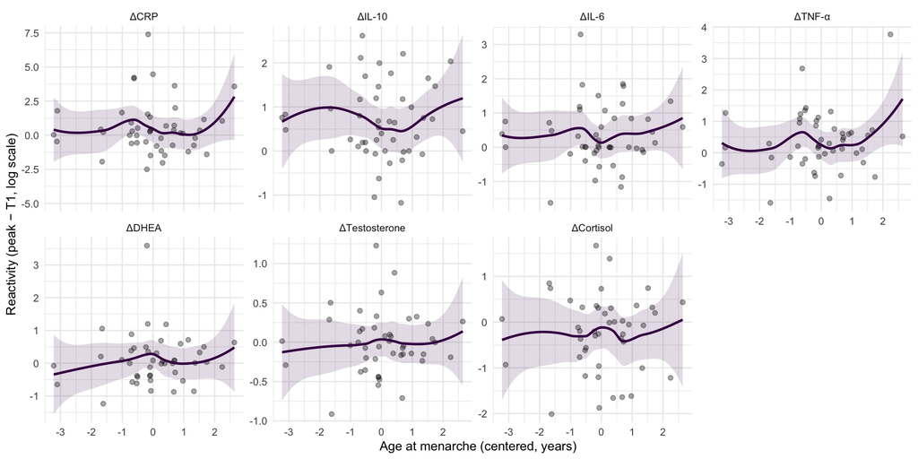

### PDS F5: perceived timing (1=much earlier, 5=much later)

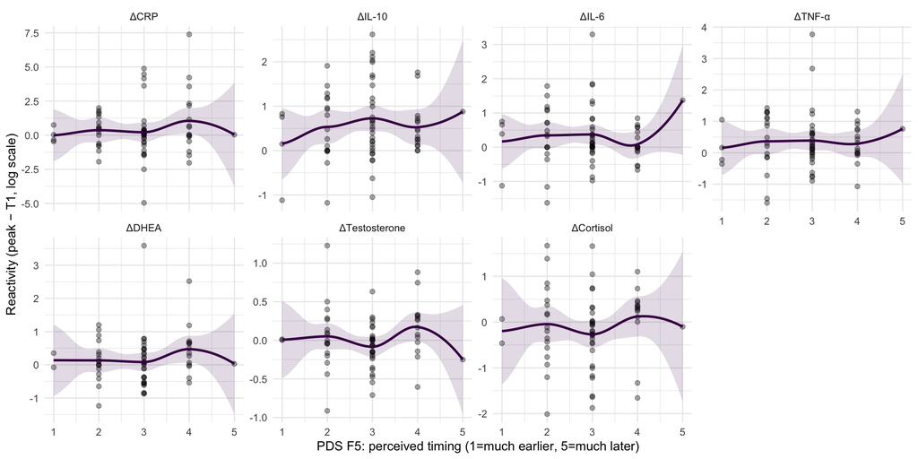

# Hypothesis 2: Puberty and Raw Biomarker Levels

Correlations between pubertal development and raw biomarker levels at each timepoint (T1–T4).

```r
for (pv in puberty_vars) {
  cat("\n\n##", puberty_label_map[[pv]], "\n\n")
  bio_vars <- c("CRP_log", "IL10_log", "IL6_log", "TNFalpha_log",
                "DHEA_log", "Testosterone_log", "Cortisol_log")

  corr_long <- map_dfr(bio_vars, function(bv) {
    map_dfr(1:4, function(tp) {
      dat <- biomarker_levels |>
        filter(Time == tp) |>
        select(all_of(c(bv, pv))) |>
        na.omit()
      if (nrow(dat) < 5) return(NULL)
      ct <- cor.test(dat[[bv]], dat[[pv]])
      tibble(
        Biomarker = bv,
        Timepoint = paste0("T", tp),
        r         = round(ct$estimate, 3),
        p_raw     = ct$p.value
      )
    })
  }) |>
    mutate(group = if_else(
      Biomarker %in% c("CRP_log", "IL10_log", "IL6_log", "TNFalpha_log"),
      "Immune", "Hormones"
    )) |>
    group_by(group) |>
    mutate(p_fdr = round(p.adjust(p_raw, method = "fdr"), 4)) |>
    ungroup()

  corr_tbl <- corr_long |>
    pivot_wider(id_cols = Biomarker, names_from = Timepoint,
                values_from = c(r, p_fdr),
                names_glue = "{Timepoint}_{.value}") |>
    select(Biomarker, T1_r, T1_p_fdr, T2_r, T2_p_fdr, T3_r, T3_p_fdr, T4_r, T4_p_fdr)

  corr_tbl |>
    mutate(across(ends_with("_p_fdr"), \(x) cell_spec(
      round(x, 4), bold = !is.na(x) & x < 0.05,
      color = if_else(!is.na(x) & x < 0.05, "#2166ac", "black")
    ))) |>
    kable(escape = FALSE,
          col.names = c("Biomarker", "r", "p (FDR)", "r", "p (FDR)", "r", "p (FDR)", "r", "p (FDR)"),
          caption   = paste0("Correlations: ", puberty_label_map[[pv]],
                             " × biomarker levels (FDR-adjusted within immune/hormones; bold = p_FDR < .05)")) |>
    add_header_above(c(" " = 1, "T1" = 2, "T2" = 2, "T3" = 2, "T4" = 2)) |>
    kable_styling(bootstrap_options = "hover", full_width = FALSE) |>
    print()
}
```

## Pubertal Status (Composite)

Correlations: Pubertal Status (Composite) × biomarker levels (FDR-adjusted within immune/hormones; bold = p_FDR

| Biomarker | T1 r | T1 p (FDR) | T2 r | T2 p (FDR) | T3 r | T3 p (FDR) | T4 r | T4 p (FDR) |
| --- | --- | --- | --- | --- | --- | --- | --- | --- |
| CRP_log | 0.017 | 0.9711 | 0.103 | 0.8851 | 0.092 | 0.8851 | 0.093 | 0.8851 |
| IL10_log | -0.223 | 0.5883 | -0.142 | 0.7658 | -0.070 | 0.9049 | -0.148 | 0.7658 |
| IL6_log | -0.183 | 0.5883 | -0.068 | 0.9049 | -0.059 | 0.9049 | 0.003 | 0.9803 |
| TNFalpha_log | -0.193 | 0.5883 | -0.049 | 0.9127 | -0.013 | 0.9711 | 0.025 | 0.9711 |
| DHEA_log | 0.350 | 0.009 | 0.390 | 0.008 | 0.337 | 0.0123 | 0.379 | 0.008 |
| Testosterone_log | 0.199 | 0.1327 | 0.261 | 0.0567 | 0.310 | 0.0204 | 0.280 | 0.0396 |
| Cortisol_log | 0.045 | 0.846 | 0.096 | 0.5892 | 0.018 | 0.8797 | -0.034 | 0.8505 |

# Hypothesis 3a: Depression and Biomarker Correlations

*Hypothesis 3 (manuscript): Pearson correlations between CES-DC total score and (a) log-transformed biomarker concentrations at each of the four timepoints (T1–T4), FDR-corrected separately within immune markers and hormones, and (b) each of the 13 reactivity difference scores, FDR-corrected within each reactivity domain.*

```r
dep |>
  summarise(
    n    = sum(!is.na(CESD_total)),
    Mean = round(mean(CESD_total, na.rm = TRUE), 2),
    SD   = round(sd(CESD_total,   na.rm = TRUE), 2),
    Min  = round(min(CESD_total,  na.rm = TRUE), 2),
    Max  = round(max(CESD_total,  na.rm = TRUE), 2)
  ) |>
  kable(caption = "CES-DC descriptives") |>
  kable_styling(bootstrap_options = "hover", full_width = FALSE)
```

CES-DC descriptives

| n | Mean | SD | Min | Max |
| --- | --- | --- | --- | --- |
| 77 | 15.23 | 9.47 | 1 | 44 |

## Depression × Raw Biomarker Levels

```r
dep_levels <- biomarker_levels |>
  left_join(dep, by = "SampleID")

bio_vars <- c("CRP_log", "IL10_log", "IL6_log", "TNFalpha_log",
              "DHEA_log", "Testosterone_log", "Cortisol_log")

dep_corr_long <- map_dfr(bio_vars, function(bv) {
  map_dfr(1:4, function(tp) {
    dat <- dep_levels |> filter(Time == tp) |>
      select(all_of(c(bv, "CESD_total"))) |> na.omit()
    if (nrow(dat) < 5) return(NULL)
    ct <- cor.test(dat[[bv]], dat$CESD_total)
    tibble(Biomarker = bv, Timepoint = paste0("T", tp),
           r = round(ct$estimate, 3), p_raw = ct$p.value)
  })
}) |>
  mutate(group = if_else(
    Biomarker %in% c("CRP_log", "IL10_log", "IL6_log", "TNFalpha_log"),
    "Immune", "Hormones"
  )) |>
  group_by(group) |>
  mutate(p_fdr = round(p.adjust(p_raw, method = "fdr"), 4)) |>
  ungroup()

dep_corr_tbl <- dep_corr_long |>
  pivot_wider(id_cols = Biomarker, names_from = Timepoint,
              values_from = c(r, p_fdr),
              names_glue = "{Timepoint}_{.value}") |>
  select(Biomarker, T1_r, T1_p_fdr, T2_r, T2_p_fdr, T3_r, T3_p_fdr, T4_r, T4_p_fdr)

dep_corr_tbl |>
  mutate(across(ends_with("_p_fdr"), \(x) cell_spec(
    round(x, 4), bold = !is.na(x) & x < 0.05,
    color = if_else(!is.na(x) & x < 0.05, "#2166ac", "black")
  ))) |>
  kable(escape = FALSE,
        col.names = c("Biomarker", "r", "p (FDR)", "r", "p (FDR)", "r", "p (FDR)", "r", "p (FDR)"),
        caption   = "Correlations: CES-DC × biomarker levels (FDR-adjusted p-values; bold = p_FDR < .05)") |>
  add_header_above(c(" " = 1, "T1" = 2, "T2" = 2, "T3" = 2, "T4" = 2)) |>
  kable_styling(bootstrap_options = "hover", full_width = FALSE)
```

Correlations: CES-DC × biomarker levels (FDR-adjusted p-values; bold = p_FDR

| Biomarker | T1 r | T1 p (FDR) | T2 r | T2 p (FDR) | T3 r | T3 p (FDR) | T4 r | T4 p (FDR) |
| --- | --- | --- | --- | --- | --- | --- | --- | --- |
| CRP_log | 0.184 | 0.7757 | 0.259 | 0.4911 | 0.109 | 0.7757 | 0.118 | 0.7757 |
| IL10_log | 0.042 | 0.8544 | -0.076 | 0.7757 | -0.091 | 0.7757 | -0.164 | 0.7757 |
| IL6_log | 0.077 | 0.7757 | 0.106 | 0.7757 | 0.106 | 0.7757 | 0.034 | 0.8544 |
| TNFalpha_log | 0.020 | 0.8663 | -0.033 | 0.8544 | -0.100 | 0.7757 | -0.030 | 0.8544 |
| DHEA_log | 0.122 | 0.9918 | 0.083 | 0.9918 | -0.020 | 0.9918 | 0.035 | 0.9918 |
| Testosterone_log | -0.006 | 0.9918 | -0.001 | 0.9918 | -0.140 | 0.9918 | -0.034 | 0.9918 |
| Cortisol_log | -0.110 | 0.9918 | 0.026 | 0.9918 | -0.097 | 0.9918 | 0.063 | 0.9918 |

**Results.** CES-DC total score was correlated with log-transformed biomarker concentrations at each of the four timepoints (T1–T4). FDR correction was applied separately within immune markers (CRP, IL-10, IL-6, TNF-α) and hormones (DHEA, Testosterone, Cortisol). No significant associations survived FDR correction.

## Depression × Reactivity

```r
dep_reactivity <- all_difference |>
  left_join(dep, by = "SampleID") |>
  select(-SampleID) |>
  na.omit()

dep_react_corrs <- map_dfr(setNames(reactivity_vars, reactivity_labels), function(rv) {
  ct <- cor.test(dep_reactivity[[rv]], dep_reactivity$CESD_total)
  tibble(r = round(ct$estimate, 3), p_raw = ct$p.value)
}, .id = "Reactivity") |>
  mutate(domain = case_when(
    str_detect(Reactivity, "^ΔHR")                                        ~ "HR",
    Reactivity %in% c("ΔCRP", "ΔIL-10", "ΔIL-6", "ΔTNF-α")             ~ "Immune",
    Reactivity %in% c("ΔDHEA", "ΔTestosterone", "ΔCortisol")             ~ "Hormones",
    TRUE                                                                   ~ "Subjective"
  )) |>
  group_by(domain) |>
  mutate(p_fdr = round(p.adjust(p_raw, method = "fdr"), 4)) |>
  ungroup()

dep_react_corrs |>
  select(Reactivity, r, p_fdr) |>
  mutate(p_fdr = cell_spec(p_fdr, bold = !is.na(p_fdr) & p_fdr < 0.05,
    color = if_else(!is.na(p_fdr) & p_fdr < 0.05, "#2166ac", "black"))) |>
  kable(escape = FALSE, col.names = c("Reactivity outcome", "r", "p (FDR)"),
        caption = "Correlations: CES-DC × reactivity (FDR-adjusted; bold = p_FDR < .05)") |>
  kable_styling(bootstrap_options = "hover", full_width = FALSE)
```

Correlations: CES-DC × reactivity (FDR-adjusted; bold = p_FDR

| Reactivity outcome | r | p (FDR) |
| --- | --- | --- |
| ΔHR: Task vs. Rest | -0.033 | 0.8261 |
| ΔHR: SC vs. SD | 0.121 | 0.5507 |
| ΔHR: SC vs. Other | 0.175 | 0.5507 |
| ΔHR: SC vs. Fixation-Cross | 0.126 | 0.5507 |
| ΔCRP | 0.132 | 0.7441 |
| ΔIL-10 | -0.227 | 0.4799 |
| ΔIL-6 | -0.079 | 0.7926 |
| ΔTNF-α | 0.005 | 0.9748 |
| ΔDHEA | -0.015 | 0.9196 |
| ΔTestosterone | 0.206 | 0.359 |
| ΔCortisol | 0.173 | 0.359 |
| ΔSubj Stress: SC vs. SD | 0.006 | 0.9652 |
| ΔSubj Stress: SC vs. Other | 0.054 | 0.9652 |

**Results.** CES-DC total score was correlated with each of the 13 reactivity difference scores. FDR correction was applied within each reactivity domain (HR: 4 tests; immune: 4 tests; hormones: 3 tests; subjective: 2 tests). No significant associations survived FDR correction.

# Hypothesis 3b: BFNES and Biomarker Correlations

*Hypothesis 3 (manuscript): Pearson correlations between BFNES total score and (a) log-transformed biomarker concentrations at each of the four timepoints (T1–T4), FDR-corrected separately within immune markers and hormones, and (b) each of the 13 reactivity difference scores, FDR-corrected within each reactivity domain.*

Correlations between BFNES (Brief Fear of Negative Evaluation Scale; Leary, 1983) total score and biomarker levels at each timepoint and biomarker reactivity. Items 2, 6, 7, and 10 were reverse-scored; total scores range from 12–60 with higher scores reflecting greater fear of negative evaluation.

```r
bfnes |>
  filter(!is.na(BFNES_total)) |>
  summarise(
    n    = n(),
    Mean = round(mean(BFNES_total), 2),
    SD   = round(sd(BFNES_total),   2),
    Min  = round(min(BFNES_total),  2),
    Max  = round(max(BFNES_total),  2)
  ) |>
  kable(caption = "BFNES descriptives") |>
  kable_styling(bootstrap_options = "hover", full_width = FALSE)
```

BFNES descriptives

| n | Mean | SD | Min | Max |
| --- | --- | --- | --- | --- |
| 71 | 34.51 | 9.35 | 16 | 53 |

## FNE × Raw Biomarker Levels

```r
bfnes_levels <- biomarker_levels |>
  left_join(bfnes, by = "SampleID")

bfnes_corr_long <- map_dfr(bio_vars, function(bv) {
  map_dfr(1:4, function(tp) {
    dat <- bfnes_levels |> filter(Time == tp) |>
      select(all_of(c(bv, "BFNES_total"))) |> na.omit()
    if (nrow(dat) < 5) return(NULL)
    ct <- cor.test(dat[[bv]], dat$BFNES_total)
    tibble(Biomarker = bv, Timepoint = paste0("T", tp),
           r = round(ct$estimate, 3), p_raw = ct$p.value)
  })
}) |>
  mutate(group = if_else(
    Biomarker %in% c("CRP_log", "IL10_log", "IL6_log", "TNFalpha_log"),
    "Immune", "Hormones"
  )) |>
  group_by(group) |>
  mutate(p_fdr = round(p.adjust(p_raw, method = "fdr"), 4)) |>
  ungroup()

bfnes_corr_tbl <- bfnes_corr_long |>
  pivot_wider(id_cols = Biomarker, names_from = Timepoint,
              values_from = c(r, p_fdr),
              names_glue = "{Timepoint}_{.value}") |>
  select(Biomarker, T1_r, T1_p_fdr, T2_r, T2_p_fdr, T3_r, T3_p_fdr, T4_r, T4_p_fdr)

bfnes_corr_tbl |>
  mutate(across(ends_with("_p_fdr"), \(x) cell_spec(
    round(x, 4), bold = !is.na(x) & x < 0.05,
    color = if_else(!is.na(x) & x < 0.05, "#2166ac", "black")
  ))) |>
  kable(escape = FALSE,
        col.names = c("Biomarker", "r", "p (FDR)", "r", "p (FDR)", "r", "p (FDR)", "r", "p (FDR)"),
        caption   = "Correlations: BFNES × biomarker levels (FDR-adjusted; bold = p_FDR < .05)") |>
  add_header_above(c(" " = 1, "T1" = 2, "T2" = 2, "T3" = 2, "T4" = 2)) |>
  kable_styling(bootstrap_options = "hover", full_width = FALSE)
```

Correlations: BFNES × biomarker levels (FDR-adjusted; bold = p_FDR

| Biomarker | T1 r | T1 p (FDR) | T2 r | T2 p (FDR) | T3 r | T3 p (FDR) | T4 r | T4 p (FDR) |
| --- | --- | --- | --- | --- | --- | --- | --- | --- |
| CRP_log | -0.236 | 0.2462 | -0.141 | 0.3558 | -0.166 | 0.3558 | -0.089 | 0.5787 |
| IL10_log | -0.146 | 0.3558 | -0.143 | 0.3558 | -0.153 | 0.3558 | -0.031 | 0.8006 |
| IL6_log | -0.172 | 0.3558 | -0.146 | 0.3558 | -0.082 | 0.5787 | -0.051 | 0.7281 |
| TNFalpha_log | -0.309 | 0.1409 | -0.235 | 0.2462 | -0.280 | 0.1656 | -0.143 | 0.3558 |
| DHEA_log | -0.001 | 0.9959 | -0.077 | 0.943 | -0.074 | 0.943 | -0.006 | 0.9959 |
| Testosterone_log | -0.096 | 0.943 | -0.032 | 0.9959 | -0.250 | 0.2634 | -0.022 | 0.9959 |
| Cortisol_log | -0.229 | 0.2634 | -0.220 | 0.2634 | -0.210 | 0.2634 | 0.047 | 0.9959 |

**Results.** BFNES total score was correlated with log-transformed biomarker concentrations at each timepoint (T1–T4). FDR correction was applied separately within immune markers and hormones. No significant associations survived FDR correction.

## FNE × Reactivity

```r
bfnes_reactivity <- all_difference |>
  left_join(bfnes, by = "SampleID") |>
  select(-SampleID) |>
  na.omit()

bfnes_react_corrs <- map_dfr(setNames(reactivity_vars, reactivity_labels), function(rv) {
  ct <- cor.test(bfnes_reactivity[[rv]], bfnes_reactivity$BFNES_total)
  tibble(r = round(ct$estimate, 3), p_raw = ct$p.value)
}, .id = "Reactivity") |>
  mutate(domain = case_when(
    str_detect(Reactivity, "^ΔHR")                                        ~ "HR",
    Reactivity %in% c("ΔCRP", "ΔIL-10", "ΔIL-6", "ΔTNF-α")             ~ "Immune",
    Reactivity %in% c("ΔDHEA", "ΔTestosterone", "ΔCortisol")             ~ "Hormones",
    TRUE                                                                   ~ "Subjective"
  )) |>
  group_by(domain) |>
  mutate(p_fdr = round(p.adjust(p_raw, method = "fdr"), 4)) |>
  ungroup()

bfnes_react_corrs |>
  select(Reactivity, r, p_fdr) |>
  mutate(p_fdr = cell_spec(p_fdr, bold = !is.na(p_fdr) & p_fdr < 0.05,
    color = if_else(!is.na(p_fdr) & p_fdr < 0.05, "#2166ac", "black"))) |>
  kable(escape = FALSE, col.names = c("Reactivity outcome", "r", "p (FDR)"),
        caption = "Correlations: BFNES × reactivity (FDR-adjusted; bold = p_FDR < .05)") |>
  kable_styling(bootstrap_options = "hover", full_width = FALSE)
```

Correlations: BFNES × reactivity (FDR-adjusted; bold = p_FDR

| Reactivity outcome | r | p (FDR) |
| --- | --- | --- |
| ΔHR: Task vs. Rest | -0.069 | 0.7445 |
| ΔHR: SC vs. SD | -0.050 | 0.7445 |
| ΔHR: SC vs. Other | 0.087 | 0.7445 |
| ΔHR: SC vs. Fixation-Cross | -0.051 | 0.7445 |
| ΔCRP | 0.006 | 0.9676 |
| ΔIL-10 | 0.037 | 0.9676 |
| ΔIL-6 | 0.107 | 0.9676 |
| ΔTNF-α | 0.049 | 0.9676 |
| ΔDHEA | 0.072 | 0.6378 |
| ΔTestosterone | 0.259 | 0.1294 |
| ΔCortisol | 0.386 | 0.0266 |
| ΔSubj Stress: SC vs. SD | 0.368 | 0.013 |
| ΔSubj Stress: SC vs. Other | 0.423 | 0.0076 |

**Results.** BFNES total score (fear of negative evaluation; range 12–60) was correlated with each of the 13 reactivity difference scores. FDR correction was applied within each reactivity domain (HR: 4 tests; immune: 4 tests; hormones: 3 tests; subjective: 2 tests). 3 significant associations were observed: ΔCortisol (r = 0.386, p<sub>FDR</sub> = 0.0266); ΔSubj Stress: SC vs. SD (r = 0.368, p<sub>FDR</sub> = 0.013); ΔSubj Stress: SC vs. Other (r = 0.423, p<sub>FDR</sub> = 0.0076).

# Supplementary and Robustness Analyses

Covariate descriptives, exclusionary sensitivity analyses (illness/bleeding-gum/smoking exclusion re-tests), and covariate-adjusted trend models formerly reported in this section have moved to `sos-bioreactivity-supplement.qmd`, along with the cross-checks tying those results back to the primary (unadjusted, full-sample) findings above. See that notebook for the full sensitivity analyses.

# Sample Timing

## Inter-Sample Intervals

Time elapsed (minutes) from the T1 sample to each subsequent collection.

```r
saliva_timing |>
  select(elapsed_T2, elapsed_T3, elapsed_T4) |>
  summarise(across(
    everything(),
    list(
      n    = \(x) sum(!is.na(x)),
      Mean = \(x) round(mean(x, na.rm = TRUE), 1),
      SD   = \(x) round(sd(x, na.rm = TRUE), 1),
      Min  = \(x) round(min(x, na.rm = TRUE), 1),
      Max  = \(x) round(max(x, na.rm = TRUE), 1)
    ),
    .names = "{.col}_{.fn}"
  )) |>
  pivot_longer(everything(),
               names_to  = c("Sample", ".value"),
               names_sep = "_(?=[^_]+$)") |>
  mutate(Sample = case_match(Sample,
    "elapsed_T2" ~ "T1 → T2",
    "elapsed_T3" ~ "T1 → T3",
    "elapsed_T4" ~ "T1 → T4"
  )) |>
  kable(caption = "Minutes elapsed from T1 to each subsequent sample") |>
  kable_styling(bootstrap_options = "hover", full_width = FALSE)
```

Minutes elapsed from T1 to each subsequent sample

| Sample | n | Mean | SD | Min | Max |
| --- | --- | --- | --- | --- | --- |
| T1 → T2 | 71 | 67.9 | 10.9 | 28 | 113 |
| T1 → T3 | 72 | 86.4 | 10.0 | 72 | 128 |
| T1 → T4 | 70 | 116.6 | 10.8 | 99 | 158 |

## Elapsed Time as Covariate in Hormone Models

Correlations between inter-sample elapsed time and hormone levels, to assess whether timing variation affects results.

```r
hormone_timing <- sos_hormones_panel |>
  left_join(saliva_timing, by = "SampleID") |>
  mutate(elapsed = case_when(
    Time == 2 ~ elapsed_T2,
    Time == 3 ~ elapsed_T3,
    Time == 4 ~ elapsed_T4,
    .default  = NA_real_
  ))

hormone_vars <- c("DHEA_log", "Testosterone_log", "Cortisol_log")

cat("### Correlation: elapsed time × hormone level at T2–T4\n\n")
```

### Correlation: elapsed time × hormone level at T2–T4

```r
map_dfr(hormone_vars, function(hv) {
  map_dfr(2:4, function(tp) {
    dat <- hormone_timing |> filter(Time == tp) |>
      select(all_of(hv), elapsed) |> na.omit()
    if (nrow(dat) < 5) return(NULL)
    ct <- cor.test(dat[[hv]], dat$elapsed)
    tibble(Hormone = hv, Timepoint = paste0("T", tp),
           r = round(ct$estimate, 3), p = round(ct$p.value, 3))
  })
}) |>
  pivot_wider(names_from = Timepoint, values_from = c(r, p),
              names_glue = "{Timepoint}_{.value}") |>
  select(Hormone, T2_r, T2_p, T3_r, T3_p, T4_r, T4_p) |>
  mutate(across(ends_with("_p"), \(x) cell_spec(
    round(x, 3), bold = x < 0.05,
    color = if_else(x < 0.05, "#2166ac", "black")
  ))) |>
  kable(escape = FALSE,
        col.names = c("Hormone", "r", "p", "r", "p", "r", "p"),
        caption = "Elapsed minutes from T1 × hormone level") |>
  add_header_above(c(" " = 1, "T2" = 2, "T3" = 2, "T4" = 2)) |>
  kable_styling(bootstrap_options = "hover", full_width = FALSE) |>
  print()
```

Elapsed minutes from T1 × hormone level

| Hormone | T2 r | T2 p | T3 r | T3 p | T4 r | T4 p |
| --- | --- | --- | --- | --- | --- | --- |
| DHEA_log | 0.067 | 0.59 | 0.081 | 0.506 | 0.076 | 0.543 |
| Testosterone_log | 0.051 | 0.685 | 0.059 | 0.628 | 0.093 | 0.452 |
| Cortisol_log | 0.092 | 0.459 | -0.015 | 0.904 | 0.063 | 0.615 |

## Time Since Waking × Sex Steroid Hormones

Wake time was recorded as free text; times after 12:00 pm were treated as implausible and set to missing. Elapsed hours = time of T1 collection minus wake time.

```r
wake_time |>
  filter(!is.na(hours_since_wake)) |>
  summarise(
    n    = n(),
    Mean = round(mean(hours_since_wake), 1),
    SD   = round(sd(hours_since_wake), 1),
    Min  = round(min(hours_since_wake), 1),
    Max  = round(max(hours_since_wake), 1)
  ) |>
  kable(caption = "Hours elapsed from waking to T1 sample collection") |>
  kable_styling(bootstrap_options = "hover", full_width = FALSE)
```

Hours elapsed from waking to T1 sample collection

| n | Mean | SD | Min | Max |
| --- | --- | --- | --- | --- |
| 45 | 6.1 | 1.7 | 2.5 | 10 |

```r
wake_hormones <- sos_hormones_panel |>
  filter(Time == 1) |>
  left_join(wake_time |> select(SampleID, hours_since_wake), by = "SampleID") |>
  left_join(
    hormones_difference |> select(SampleID, dhea_difference, test_difference, cort_difference),
    by = "SampleID"
  )

hormone_wake_outcomes <- c(
  "DHEA_log"        = "DHEA (T1 level)",
  "Testosterone_log" = "Testosterone (T1 level)",
  "Cortisol_log"    = "Cortisol (T1 level)",
  "dhea_difference" = "ΔDHEA (reactivity)",
  "test_difference" = "ΔTestosterone (reactivity)",
  "cort_difference" = "ΔCortisol (reactivity)"
)

map_dfr(names(hormone_wake_outcomes), function(hv) {
  dat <- wake_hormones |> select(all_of(hv), hours_since_wake) |> na.omit()
  if (nrow(dat) < 5) return(NULL)
  ct <- cor.test(dat[[hv]], dat$hours_since_wake)
  tibble(
    Outcome = hormone_wake_outcomes[[hv]],
    n       = nrow(dat),
    r       = round(ct$estimate, 3),
    p       = round(ct$p.value, 3)
  )
}) |>
  mutate(p = cell_spec(p, bold = p < 0.05,
    color = if_else(p < 0.05, "#2166ac", "black"))) |>
  kable(escape = FALSE,
        col.names = c("Outcome", "n", "r", "p"),
        caption = "Correlations: hours since waking × sex steroid hormone levels and reactivity") |>
  kable_styling(bootstrap_options = "hover", full_width = FALSE)
```

Correlations: hours since waking × sex steroid hormone levels and reactivity

| Outcome | n | r | p |
| --- | --- | --- | --- |
| DHEA (T1 level) | 43 | 0.064 | 0.685 |
| Testosterone (T1 level) | 43 | -0.061 | 0.699 |
| Cortisol (T1 level) | 43 | 0.245 | 0.114 |
| ΔDHEA (reactivity) | 40 | -0.042 | 0.796 |
| ΔTestosterone (reactivity) | 40 | 0.021 | 0.897 |
| ΔCortisol (reactivity) | 40 | -0.314 | 0.048 |

# Correlation Matrices by Domain

Circle size and color reflect correlation magnitude (red = negative, blue = positive). X marks indicate non-significant correlations (p ≥ .05).

## Bioreactivity Measures

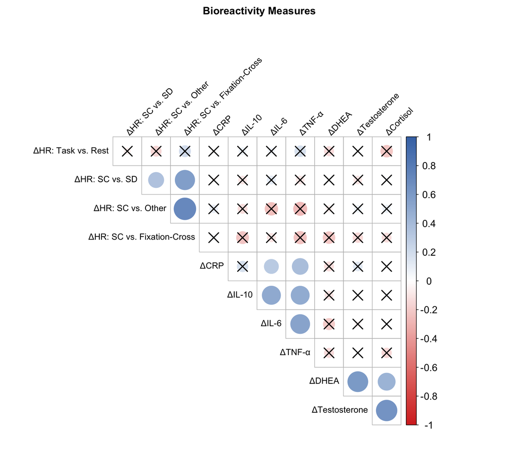

```r
bio_react_cols <- c(
  "task_rs_hr_diff", "conn_dis_hr_diff", "conn_other_hr_diff", "conn_rest_hr_diff",
  "crp_difference", "il10_difference", "il6_difference", "tnfa_difference",
  "dhea_difference", "test_difference", "cort_difference"
)
bio_react_col_labels <- c(
  "ΔHR: Task vs. Rest", "ΔHR: SC vs. SD", "ΔHR: SC vs. Other", "ΔHR: SC vs. Fixation-Cross",
  "ΔCRP", "ΔIL-10", "ΔIL-6", "ΔTNF-α", "ΔDHEA", "ΔTestosterone", "ΔCortisol"
)

bio_mat2 <- all_difference |>
  select(all_of(bio_react_cols)) |>
  setNames(bio_react_col_labels) |>
  as.matrix()

bio_rc2 <- rcorr(bio_mat2)
plot_sig_corrplot(bio_rc2$r, bio_rc2$P, "Bioreactivity Measures")
```

## Outcome Measures

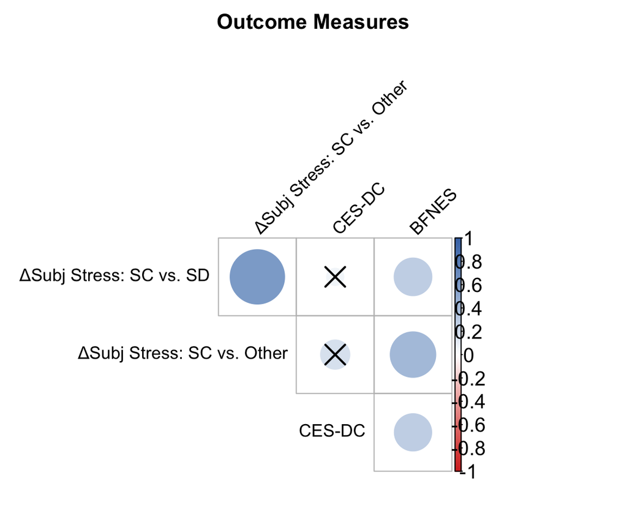

```r
outcome_mat <- all_difference |>
  select(SampleID, subj_scsd_difference, subj_scother_difference) |>
  left_join(dep   |> select(SampleID, CESD_total),  by = "SampleID") |>
  left_join(bfnes |> select(SampleID, BFNES_total), by = "SampleID") |>
  select(-SampleID) |>
  setNames(c("ΔSubj Stress: SC vs. SD", "ΔSubj Stress: SC vs. Other",
             "CES-DC", "BFNES")) |>
  as.matrix()

outcome_rc <- rcorr(outcome_mat)
plot_sig_corrplot(outcome_rc$r, outcome_rc$P, "Outcome Measures")
```

## All Measures

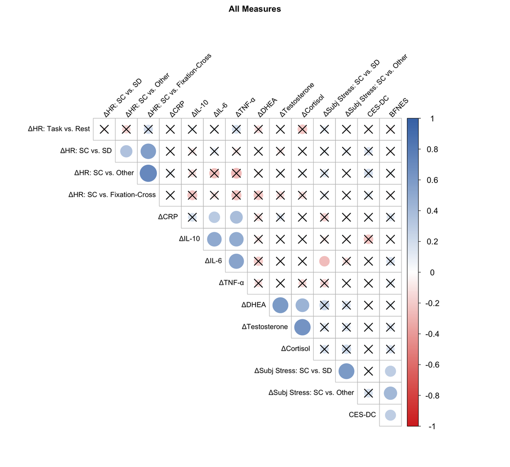

```r
all_measures_mat <- all_difference |>
  left_join(dep   |> select(SampleID, CESD_total),  by = "SampleID") |>
  left_join(bfnes |> select(SampleID, BFNES_total), by = "SampleID") |>
  select(all_of(bio_react_cols), subj_scsd_difference, subj_scother_difference,
         CESD_total, BFNES_total) |>
  setNames(c(bio_react_col_labels,
             "ΔSubj Stress: SC vs. SD", "ΔSubj Stress: SC vs. Other",
             "CES-DC", "BFNES")) |>
  as.matrix()

all_rc <- rcorr(all_measures_mat)
plot_sig_corrplot(all_rc$r, all_rc$P, "All Measures")
```

## Raw HR & Biomarker (T1) Measures

*Raw (non-reactivity) counterparts of the measures above: HR by condition (not difference scores), and each biomarker’s T1 (baseline) concentration.*

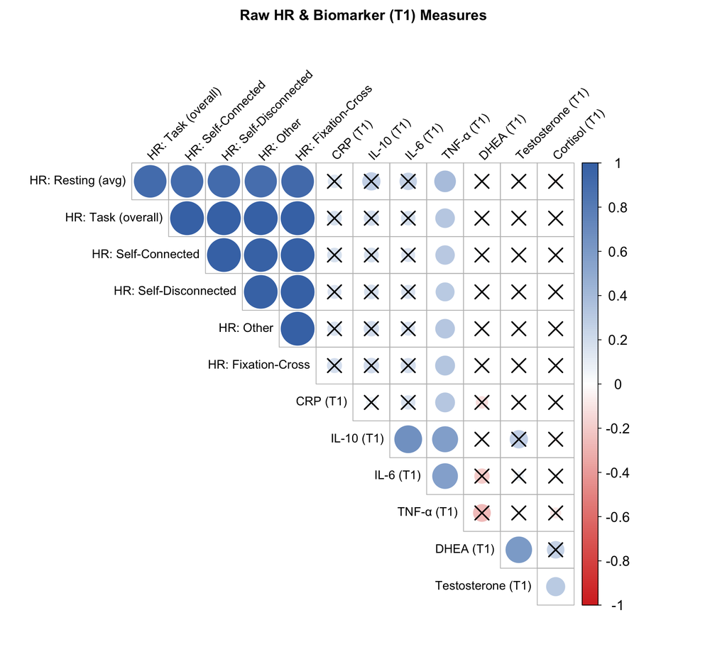

```r
raw_biohr_df <- hr_final_wide |>
  select(SampleID, resting_avg, Task, `Self-Connected`, `Self-Disconnected`, Other, `Fixation-Cross`) |>
  left_join(sos_crp_wide       |> select(SampleID, CRP_log_1), by = "SampleID") |>
  left_join(sos_cytokines_wide |> select(SampleID, IL10_log_1, IL6_log_1, TNFalpha_log_1), by = "SampleID") |>
  left_join(sos_hormones_wide  |> select(SampleID, DHEA_log_1, Testosterone_log_1, Cortisol_log_1), by = "SampleID")

raw_biohr_cols <- c(
  "resting_avg", "Task", "Self-Connected", "Self-Disconnected", "Other", "Fixation-Cross",
  "CRP_log_1", "IL10_log_1", "IL6_log_1", "TNFalpha_log_1", "DHEA_log_1", "Testosterone_log_1", "Cortisol_log_1"
)
raw_biohr_labels <- c(
  "HR: Resting (avg)", "HR: Task (overall)", "HR: Self-Connected", "HR: Self-Disconnected",
  "HR: Other", "HR: Fixation-Cross",
  "CRP (T1)", "IL-10 (T1)", "IL-6 (T1)", "TNF-α (T1)", "DHEA (T1)", "Testosterone (T1)", "Cortisol (T1)"
)

raw_biohr_mat <- raw_biohr_df |>
  select(all_of(raw_biohr_cols)) |>
  setNames(raw_biohr_labels) |>
  as.matrix()

raw_biohr_rc <- rcorr(raw_biohr_mat)
plot_sig_corrplot(raw_biohr_rc$r, raw_biohr_rc$P, "Raw HR & Biomarker (T1) Measures")
```

## Raw Biomarker Levels (All Timepoints), HR & Subjective Stress

*The matrix above collapses each biomarker to its T1 value. This version instead keeps every biomarker at all four timepoints (T1–T4), alongside raw HR by condition and raw subjective stress ratings by condition — all raw values, no reactivity/difference scores.*

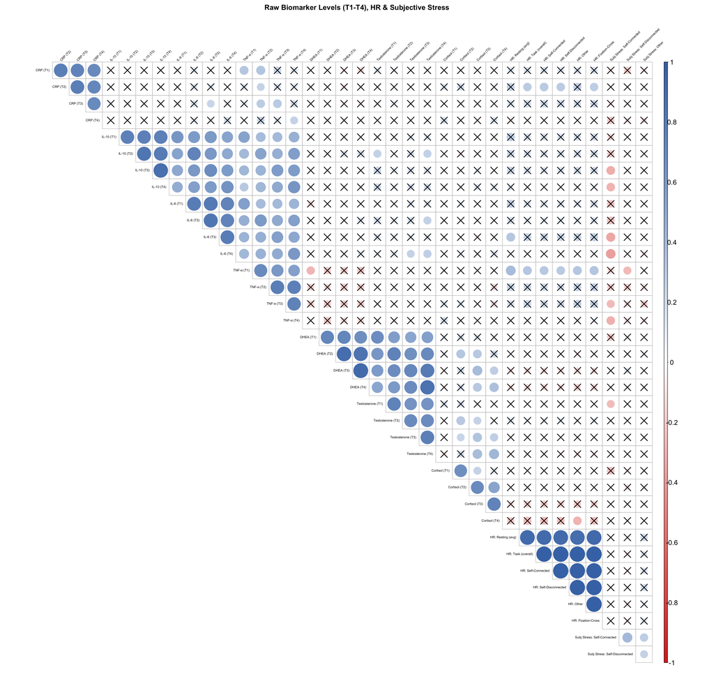

```r
raw_biomarker_tp_cols <- c(
  paste0("CRP_log_", 1:4),
  paste0("IL10_log_", 1:4),
  paste0("IL6_log_", 1:4),
  paste0("TNFalpha_log_", 1:4),
  paste0("DHEA_log_", 1:4),
  paste0("Testosterone_log_", 1:4),
  paste0("Cortisol_log_", 1:4)
)
raw_biomarker_tp_labels <- c(
  paste0("CRP (T", 1:4, ")"),
  paste0("IL-10 (T", 1:4, ")"),
  paste0("IL-6 (T", 1:4, ")"),
  paste0("TNF-α (T", 1:4, ")"),
  paste0("DHEA (T", 1:4, ")"),
  paste0("Testosterone (T", 1:4, ")"),
  paste0("Cortisol (T", 1:4, ")")
)

raw_biomarker_tp_df <- sos_crp_wide |>
  select(SampleID, all_of(paste0("CRP_log_", 1:4))) |>
  full_join(sos_cytokines_wide |> select(SampleID, all_of(c(
    paste0("IL10_log_", 1:4), paste0("IL6_log_", 1:4), paste0("TNFalpha_log_", 1:4)
  ))), by = "SampleID") |>
  full_join(sos_hormones_wide |> select(SampleID, all_of(c(
    paste0("DHEA_log_", 1:4), paste0("Testosterone_log_", 1:4), paste0("Cortisol_log_", 1:4)
  ))), by = "SampleID")

raw_hr_subj_cols <- c(
  "resting_avg", "Task", "Self-Connected", "Self-Disconnected", "Other", "Fixation-Cross",
  "selfconnected_subj_stress", "selfdisconnected_subj_stress", "other_subj_stress"
)
raw_hr_subj_labels <- c(
  "HR: Resting (avg)", "HR: Task (overall)", "HR: Self-Connected", "HR: Self-Disconnected",
  "HR: Other", "HR: Fixation-Cross",
  "Subj Stress: Self-Connected", "Subj Stress: Self-Disconnected", "Subj Stress: Other"
)

raw_alltp_df <- raw_biomarker_tp_df |>
  left_join(
    hr_final_wide |> select(SampleID, resting_avg, Task, `Self-Connected`, `Self-Disconnected`, Other, `Fixation-Cross`),
    by = "SampleID"
  ) |>
  left_join(
    sos_subj_stress |> select(SampleID, selfconnected_subj_stress, selfdisconnected_subj_stress, other_subj_stress),
    by = "SampleID"
  )

all_raw_tp_cols   <- c(raw_biomarker_tp_cols, raw_hr_subj_cols)
all_raw_tp_labels <- c(raw_biomarker_tp_labels, raw_hr_subj_labels)

raw_alltp_mat <- raw_alltp_df |>
  select(all_of(all_raw_tp_cols)) |>
  setNames(all_raw_tp_labels) |>
  as.matrix()

raw_alltp_rc <- rcorr(raw_alltp_mat)
plot_sig_corrplot(raw_alltp_rc$r, raw_alltp_rc$P, "Raw Biomarker Levels (T1-T4), HR & Subjective Stress",
                   tl.cex = 0.55, cl.ratio = 0.04, mar = c(0, 0, 2, 0))
```

## Raw Outcome Measures

*Raw (non-reactivity) counterparts: subjective stress ratings by condition (not difference scores), CES-DC, and BFNES.*

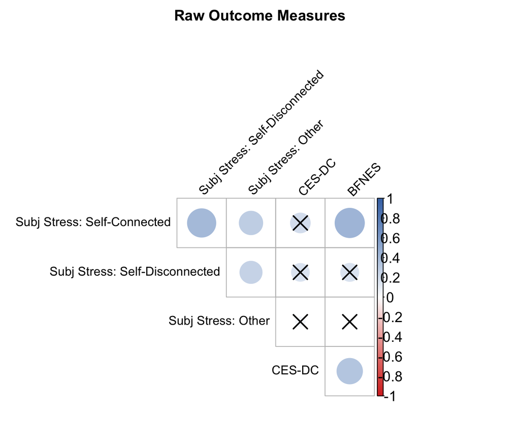

```r
raw_outcome_mat <- sos_subj_stress |>
  select(SampleID, selfconnected_subj_stress, selfdisconnected_subj_stress, other_subj_stress) |>
  left_join(dep   |> select(SampleID, CESD_total),  by = "SampleID") |>
  left_join(bfnes |> select(SampleID, BFNES_total), by = "SampleID") |>
  select(-SampleID) |>
  setNames(c("Subj Stress: Self-Connected", "Subj Stress: Self-Disconnected", "Subj Stress: Other",
             "CES-DC", "BFNES")) |>
  as.matrix()

raw_outcome_rc <- rcorr(raw_outcome_mat)
plot_sig_corrplot(raw_outcome_rc$r, raw_outcome_rc$P, "Raw Outcome Measures")
```

## Raw Puberty & Demographic Measures

*Age, BMI, hours since waking, pubertal status (PUBcomp), age at menarche, and PDS F5 perceived timing — all as raw values (not reactivity or centered/residualized versions).*

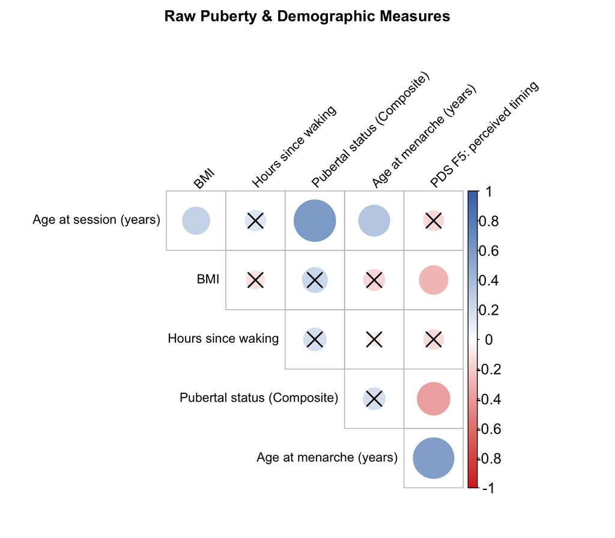

```r
raw_demo_puberty_df <- static_covariates |>
  left_join(sos_puberty |> select(SampleID, PUBcomp),               by = "SampleID") |>
  left_join(timing_df   |> select(SampleID, age_menarche, PDS_F5),  by = "SampleID")

raw_demo_puberty_cols <- c("age_at_session", "BMI", "hours_since_wake", "PUBcomp", "age_menarche", "PDS_F5")
raw_demo_puberty_labels <- c(
  "Age at session (years)", "BMI", "Hours since waking",
  "Pubertal status (Composite)", "Age at menarche (years)", "PDS F5: perceived timing"
)

raw_demo_puberty_mat <- raw_demo_puberty_df |>
  select(all_of(raw_demo_puberty_cols)) |>
  setNames(raw_demo_puberty_labels) |>
  as.matrix()

raw_demo_puberty_rc <- rcorr(raw_demo_puberty_mat)
plot_sig_corrplot(raw_demo_puberty_rc$r, raw_demo_puberty_rc$P, "Raw Puberty & Demographic Measures")
```

## All Raw Measures

*Everything above combined into a single matrix: raw HR, raw biomarker T1 levels, raw subjective stress, CES-DC, BFNES, and raw puberty/demographic variables.*

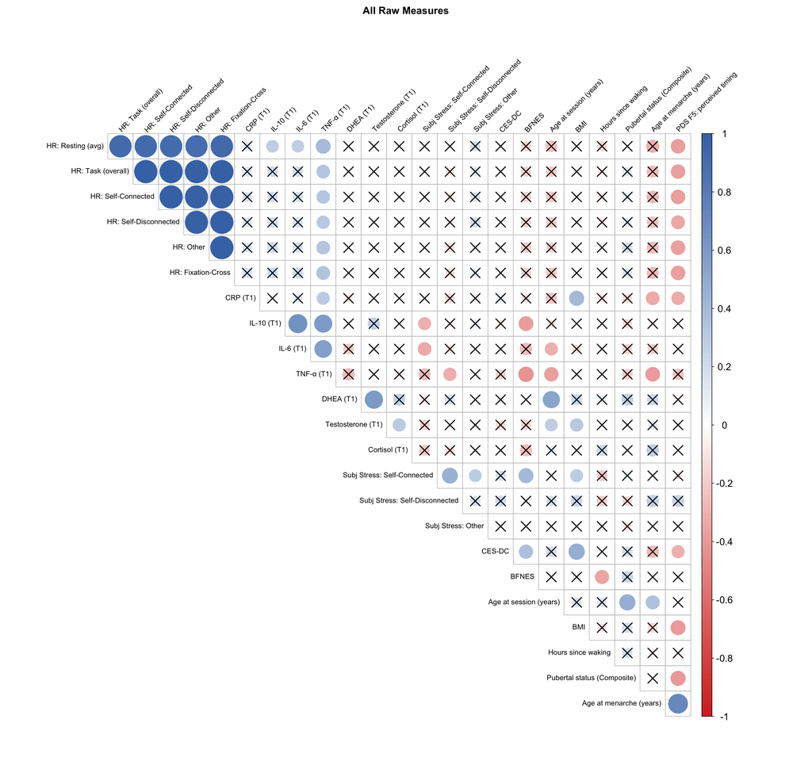

```r
all_raw_df <- raw_biohr_df |>
  left_join(
    sos_subj_stress |> select(SampleID, selfconnected_subj_stress, selfdisconnected_subj_stress, other_subj_stress),
    by = "SampleID"
  ) |>
  left_join(dep   |> select(SampleID, CESD_total),  by = "SampleID") |>
  left_join(bfnes |> select(SampleID, BFNES_total), by = "SampleID") |>
  left_join(raw_demo_puberty_df |> select(SampleID, all_of(raw_demo_puberty_cols)), by = "SampleID")

all_raw_cols <- c(
  raw_biohr_cols,
  "selfconnected_subj_stress", "selfdisconnected_subj_stress", "other_subj_stress",
  "CESD_total", "BFNES_total",
  raw_demo_puberty_cols
)
all_raw_labels <- c(
  raw_biohr_labels,
  "Subj Stress: Self-Connected", "Subj Stress: Self-Disconnected", "Subj Stress: Other",
  "CES-DC", "BFNES",
  raw_demo_puberty_labels
)

all_raw_mat <- all_raw_df |>
  select(all_of(all_raw_cols)) |>
  setNames(all_raw_labels) |>
  as.matrix()

all_raw_rc <- rcorr(all_raw_mat)
plot_sig_corrplot(all_raw_rc$r, all_raw_rc$P, "All Raw Measures", tl.cex = 0.85, cl.ratio = 0.08, mar = c(0, 0, 2, 0))
```

*Note: like the reactivity-based matrices above, these raw-variable matrices display raw uncorrected p-values — they are descriptive/exploratory only and not used for inference.*

# FDR Correction Audit

This section verifies that (1) FDR correction is applied using the correct family definitions throughout, and (2) significance markers in correlation matrices match the FDR-adjusted p-value tables.

## FDR Family Definitions

```r
tibble::tribble(
  ~Analysis,                         ~`FDR family`,                              ~`N tests`,
  "Biomarker time trends (LMM)",     "Immune markers (CRP, IL-10, IL-6, TNF-α)", "4",
  "Biomarker time trends (LMM)",     "Hormones (DHEA, Testosterone, Cortisol)",  "3",
  "Peak vs. T1 t-tests",             "Immune markers",                           "4",
  "Peak vs. T1 t-tests",             "Hormones",                                 "3",
  "Puberty × reactivity (corr)",     "HR outcomes (per puberty/timing var)",     "4",
  "Puberty × reactivity (corr)",     "Immune outcomes (per puberty/timing var)", "4",
  "Puberty × reactivity (corr)",     "Hormone outcomes (per puberty/timing var)","3",
  "Puberty × reactivity (corr)",     "Subjective outcomes (per puberty/timing var)","2",
  "Puberty × reactivity (regression)","Per predictor term across 13 outcomes",    "13",
  "Timing joint regression",          "Per predictor term across 13 outcomes",    "13",
  "CES-DC × biomarker levels",        "Immune markers (4 bio × 4 tp)",            "16",
  "CES-DC × biomarker levels",        "Hormones (3 bio × 4 tp)",                  "12",
  "CES-DC × reactivity",              "HR",                                       "4",
  "CES-DC × reactivity",              "Immune",                                   "4",
  "CES-DC × reactivity",              "Hormones",                                 "3",
  "CES-DC × reactivity",              "Subjective",                               "2",
  "BFNES × biomarker levels",         "Immune markers (4 bio × 4 tp)",            "16",
  "BFNES × biomarker levels",         "Hormones (3 bio × 4 tp)",                  "12",
  "BFNES × reactivity",               "HR",                                       "4",
  "BFNES × reactivity",               "Immune",                                   "4",
  "BFNES × reactivity",               "Hormones",                                 "3",
  "BFNES × reactivity",               "Subjective",                               "2"
) |>
  kable(caption = "FDR correction family definitions across all analyses") |>
  kable_styling(bootstrap_options = c("hover", "striped"), full_width = FALSE)
```

FDR correction family definitions across all analyses

| Analysis | FDR family | N tests |
| --- | --- | --- |
| Biomarker time trends (LMM) | Immune markers (CRP, IL-10, IL-6, TNF-α) | 4 |
| Biomarker time trends (LMM) | Hormones (DHEA, Testosterone, Cortisol) | 3 |
| Peak vs. T1 t-tests | Immune markers | 4 |
| Peak vs. T1 t-tests | Hormones | 3 |
| Puberty × reactivity (corr) | HR outcomes (per puberty/timing var) | 4 |
| Puberty × reactivity (corr) | Immune outcomes (per puberty/timing var) | 4 |
| Puberty × reactivity (corr) | Hormone outcomes (per puberty/timing var) | 3 |
| Puberty × reactivity (corr) | Subjective outcomes (per puberty/timing var) | 2 |
| Puberty × reactivity (regression) | Per predictor term across 13 outcomes | 13 |
| Timing joint regression | Per predictor term across 13 outcomes | 13 |
| CES-DC × biomarker levels | Immune markers (4 bio × 4 tp) | 16 |
| CES-DC × biomarker levels | Hormones (3 bio × 4 tp) | 12 |
| CES-DC × reactivity | HR | 4 |
| CES-DC × reactivity | Immune | 4 |
| CES-DC × reactivity | Hormones | 3 |
| CES-DC × reactivity | Subjective | 2 |
| BFNES × biomarker levels | Immune markers (4 bio × 4 tp) | 16 |
| BFNES × biomarker levels | Hormones (3 bio × 4 tp) | 12 |
| BFNES × reactivity | HR | 4 |
| BFNES × reactivity | Immune | 4 |
| BFNES × reactivity | Hormones | 3 |
| BFNES × reactivity | Subjective | 2 |

*Note: the exploratory end-of-document correlation matrices (Bioreactivity Measures, Outcome Measures, All Measures, and their raw-variable counterparts — Raw HR & Biomarker (T1) Measures, Raw Biomarker Levels (All Timepoints) HR & Subjective Stress, Raw Outcome Measures, Raw Puberty & Demographic Measures, All Raw Measures) display raw uncorrected p-values — they are descriptive only and not used for inference.*

## Raw vs. FDR Significant: Summary

```r
# ── Puberty × reactivity ──────────────────────────────────────────────────────
n_pub_raw <- sum(raw_allpub_mat < 0.05, na.rm = TRUE)
n_pub_fdr <- sum(fdr_allpub_mat < 0.05, na.rm = TRUE)

# ── Depression × levels ───────────────────────────────────────────────────────
n_dep_lev_raw <- sum(dep_corr_long$p_raw < 0.05, na.rm = TRUE)
n_dep_lev_fdr <- sum(dep_corr_long$p_fdr < 0.05, na.rm = TRUE)

# ── Depression × reactivity ───────────────────────────────────────────────────
n_dep_rx_raw  <- sum(dep_react_corrs$p_raw  < 0.05, na.rm = TRUE)
n_dep_rx_fdr  <- sum(dep_react_corrs$p_fdr  < 0.05, na.rm = TRUE)

# ── BFNES × levels ────────────────────────────────────────────────────────────
n_bf_lev_raw  <- sum(bfnes_corr_long$p_raw  < 0.05, na.rm = TRUE)
n_bf_lev_fdr  <- sum(bfnes_corr_long$p_fdr  < 0.05, na.rm = TRUE)

# ── BFNES × reactivity ────────────────────────────────────────────────────────
n_bf_rx_raw   <- sum(bfnes_react_corrs$p_raw  < 0.05, na.rm = TRUE)
n_bf_rx_fdr   <- sum(bfnes_react_corrs$p_fdr  < 0.05, na.rm = TRUE)

tibble::tribble(
  ~Analysis,                    ~`Total tests`, ~`Sig (raw p < .05)`, ~`Sig (FDR p < .05)`, ~`Lost to FDR`,
  "Puberty × reactivity",       nrow(raw_allpub_mat) * ncol(raw_allpub_mat), n_pub_raw, n_pub_fdr, n_pub_raw - n_pub_fdr,
  "CES-DC × biomarker levels",  nrow(dep_corr_long),   n_dep_lev_raw, n_dep_lev_fdr, n_dep_lev_raw - n_dep_lev_fdr,
  "CES-DC × reactivity",        nrow(dep_react_corrs), n_dep_rx_raw,  n_dep_rx_fdr,  n_dep_rx_raw  - n_dep_rx_fdr,
  "BFNES × biomarker levels",   nrow(bfnes_corr_long), n_bf_lev_raw,  n_bf_lev_fdr,  n_bf_lev_raw  - n_bf_lev_fdr,
  "BFNES × reactivity",         nrow(bfnes_react_corrs),n_bf_rx_raw,  n_bf_rx_fdr,   n_bf_rx_raw   - n_bf_rx_fdr
) |>
  kable(caption = "Raw vs. FDR-corrected significant tests per analysis") |>
  kable_styling(bootstrap_options = c("hover", "striped"), full_width = FALSE)
```

Raw vs. FDR-corrected significant tests per analysis

| Analysis | Total tests | Sig (raw p < .05) | Sig (FDR p < .05) | Lost to FDR |
| --- | --- | --- | --- | --- |
| Puberty × reactivity | 39 | 6 | 6 | 0 |
| CES-DC × biomarker levels | 28 | 1 | 0 | 1 |
| CES-DC × reactivity | 13 | 0 | 0 | 0 |
| BFNES × biomarker levels | 28 | 4 | 0 | 4 |
| BFNES × reactivity | 13 | 3 | 3 | 0 |

## Matrix vs. Table Agreement: Puberty

```r
# The corrplot uses fdr_allpub_mat; the table also uses fdr_allpub_mat.
# These are the same object, so agreement is guaranteed — this chunk confirms it.
corrplot_sig <- fdr_allpub_mat < 0.05
table_sig    <- fdr_allpub_mat < 0.05

n_disagree <- sum(corrplot_sig != table_sig, na.rm = TRUE)

if (n_disagree == 0) {
  cat("✅ PASS: corrplot significance markers and FDR p-value table agree on all",
      sum(!is.na(fdr_allpub_mat)), "cells.\n")
} else {
  cat("❌ FAIL:", n_disagree, "cell(s) disagree between the corrplot and the table.\n")
  which(corrplot_sig != table_sig, arr.ind = TRUE) |>
    as.data.frame() |>
    mutate(row_label = all_pub_labels[row], col_label = reactivity_labels[col]) |>
    select(row_label, col_label) |>
    print()
}
```

```
✅ PASS: corrplot significance markers and FDR p-value table agree on all 39 cells.
```

## Matrix vs. Table Agreement: Depression & BFNES

```r
# Dep and BFNES analyses have no corrplot — only the FDR tables.
# Check that p_fdr values in the stored objects match a fresh recomputation.

check_fdr <- function(long_df, group_var = "group", raw_col = "p_raw", fdr_col = "p_fdr", label = "") {
  recomputed <- long_df |>
    group_by(.data[[group_var]]) |>
    mutate(p_fdr_check = round(p.adjust(.data[[raw_col]], method = "fdr"), 4)) |>
    ungroup()

  n_mismatch <- sum(
    abs(recomputed[[fdr_col]] - recomputed$p_fdr_check) > 1e-6,
    na.rm = TRUE
  )

  if (n_mismatch == 0) {
    cat("✅ PASS", label, "— stored p_fdr matches recomputed FDR on all rows.\n")
  } else {
    cat("❌ FAIL", label, "—", n_mismatch, "row(s) differ.\n")
  }
}

check_fdr(dep_corr_long,   label = "CES-DC × biomarker levels")
```

```
✅ PASS CES-DC × biomarker levels — stored p_fdr matches recomputed FDR on all rows.
```

```r
check_fdr(bfnes_corr_long, label = "BFNES × biomarker levels")
```

```
✅ PASS BFNES × biomarker levels — stored p_fdr matches recomputed FDR on all rows.
```

```r
# Reactivity tables use domain grouping
check_fdr(dep_react_corrs,   group_var = "domain", label = "CES-DC × reactivity")
```

```
✅ PASS CES-DC × reactivity — stored p_fdr matches recomputed FDR on all rows.
```

```r
check_fdr(bfnes_react_corrs, group_var = "domain", label = "BFNES × reactivity")
```

```
✅ PASS BFNES × reactivity — stored p_fdr matches recomputed FDR on all rows.
```

## Puberty Raw vs. FDR: Cell-Level Detail

```r
# Show every cell where raw and FDR significance differ (informational only)
raw_sig_pub <- raw_allpub_mat < 0.05
fdr_sig_pub <- fdr_allpub_mat < 0.05

changed <- which(raw_sig_pub != fdr_sig_pub, arr.ind = TRUE)

if (nrow(changed) == 0) {
  cat("No cells changed significance status after FDR correction.\n")
} else {
  data.frame(
    `Puberty var`    = all_pub_labels[changed[, 1]],
    `Reactivity`     = reactivity_labels[changed[, 2]],
    `r`              = round(all_pub_corrs$r[all_pub_labels, reactivity_labels][changed], 3),
    `p (raw)`        = round(raw_allpub_mat[changed], 4),
    `p (FDR)`        = round(fdr_allpub_mat[changed], 4),
    `Raw sig`        = raw_sig_pub[changed],
    `FDR sig`        = fdr_sig_pub[changed],
    check.names = FALSE
  ) |>
    arrange(`p (FDR)`) |>
    kable(caption = "Cells where raw p < .05 but FDR p ≥ .05 (or vice versa)") |>
    kable_styling(bootstrap_options = "hover", full_width = FALSE)
}
```

```
No cells changed significance status after FDR correction.
```